# GESIS Spring Seminar 23

Comparative Social Research with Multi-Group SEM

Daniel Seddig, Eldad Davidov, Peter Schmidt, Yannick Diehl

Day 2 - 28.02.2023

# Packages

```r
# basic tools
library(tidyverse)

# checking data
library(MVN)
library(correlation)
library(performance)
library(parameters)
library(insight)

# building the models
library(lavaan)

# cheking the models
library(semTools)

# model visualization
library(semPlot)
library(semptools)
```

# Data

```r
ESS07 <- read.csv("../data/ESS07.csv")
```

# Confirmatory factor analysis

Many variables in the social and behavioral sciences represent hypothetical constructs (e.g., traits, attitudes, values)

Direct access to hypothetical constructs is rare. Many constructs can only be captured by (multiple) observable indicators (e.g., in a questionnaire)

It is assumed that such indicators are manifestations of hypothetical constructs - Manifest indicators: directly observable - Latent variables: not directly observable

We need a model that is able to conceptualize the relationship between manifest indicators and latent variables

The classic test theory (**novick_axioms_1966?**)

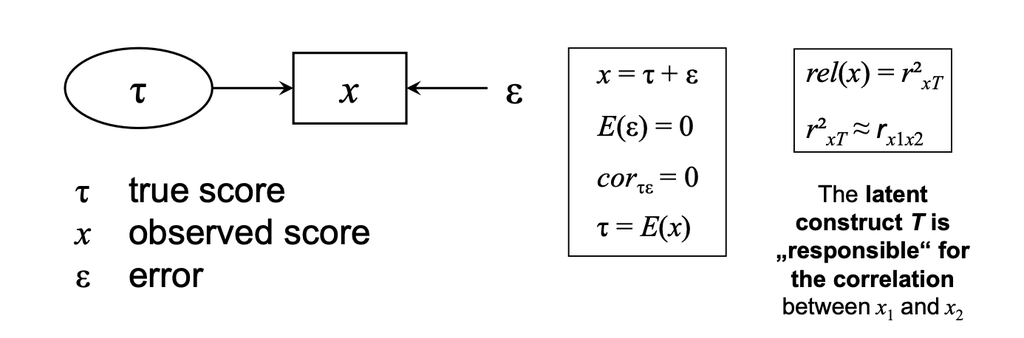

## Procedure

### Step 1

**Translation of the theoretical model into a measurement model**

We need a model that is able to conceptualize the relationship between manifest indicators and latent variables

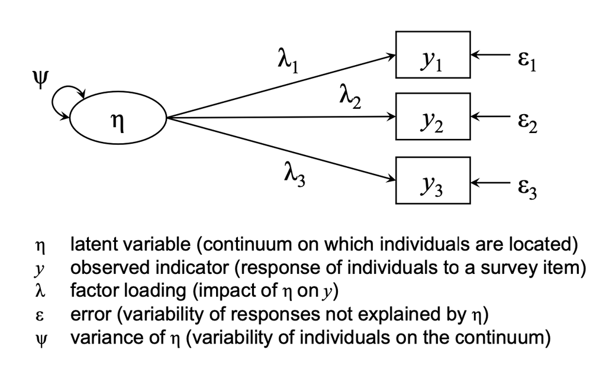

The formal expression is:

$$\begin{split}
y_1=\lambda_1\eta+\epsilon_1 \\
y_2=\lambda_2\eta+\epsilon_2 \\
y_3=\lambda_3\eta+\epsilon_3
\end{split}$$

$$\boldsymbol{Y}=\boldsymbol{\Lambda}\eta+\boldsymbol{E}$$

### Step 2

**Checking whether it is a reflexive or formative construct**

Test the hypothesized relationship between observed indicators and latent variables

- Reflective measurement: indicators are “effects” of the latent variable
- Formative measurement: latent variable is “caused” or composed by the manifest indicators

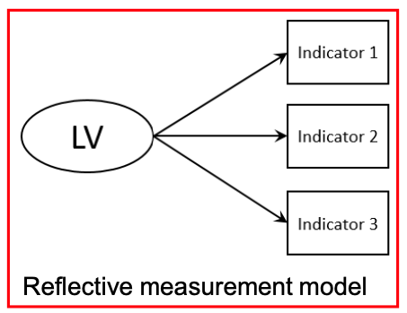

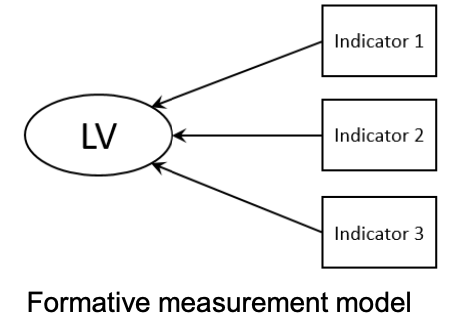

### Step 3

**Specification of the model (Choose a method to assign a scale to the latent variable)**

- Reference indicator method: factor loading of one indicator is fixed to 1.0
- Fixed factor method: the factor variance is fixed to 1.0

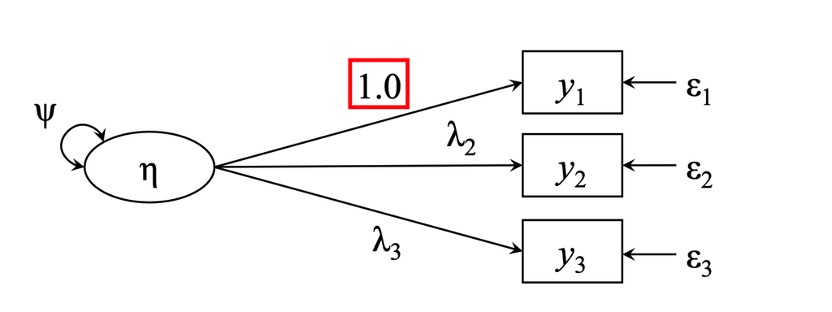

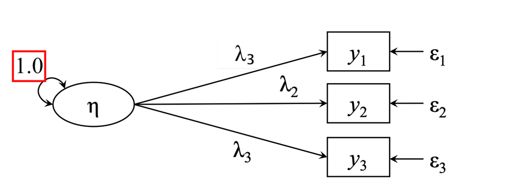

### Step 4

**Checking the model assumptions (ML estimation requirements)**

- Sample size is sufficiently large (ratio of number of cases and number of parameters - N:q rule => 20:1 or 10:1)
- Items are continuous and multivariate normal (case of non-normal data standard errors and $\chi^2$-statistics should be adjusted - e.g., robust ML = MLR)
  - Small samples (< 100): overestimation of $\chi^2_{ML}$
  - Large samples (> 400): $\chi^2_{ML}$ is almost always significant
- Problem: $\chi^2$ is sensitive to sample size
  - The importance of small discrepancies is inflated
  - H0 may be rejected although the model is a good one

### Step 5

**Checking wether the model is identified**

Complexity of a CFA model is limited by the total **number of observations** (p) and the **number of unknown model parameters** (q)

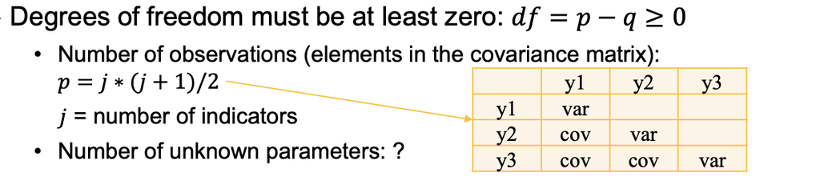

The following applies:

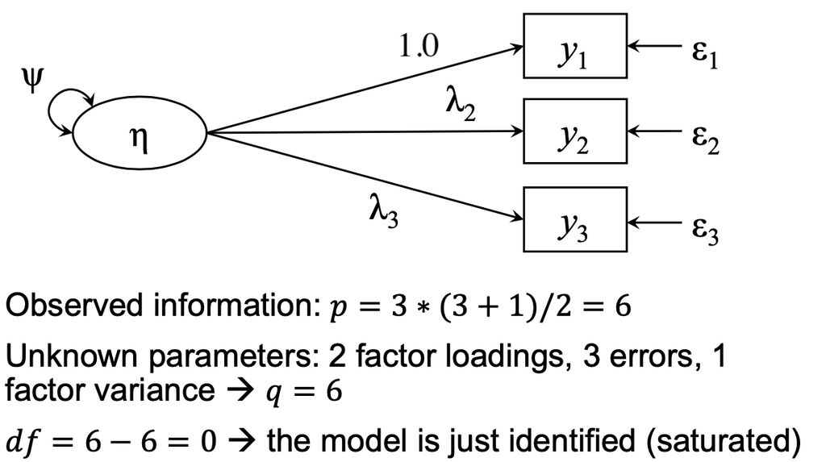

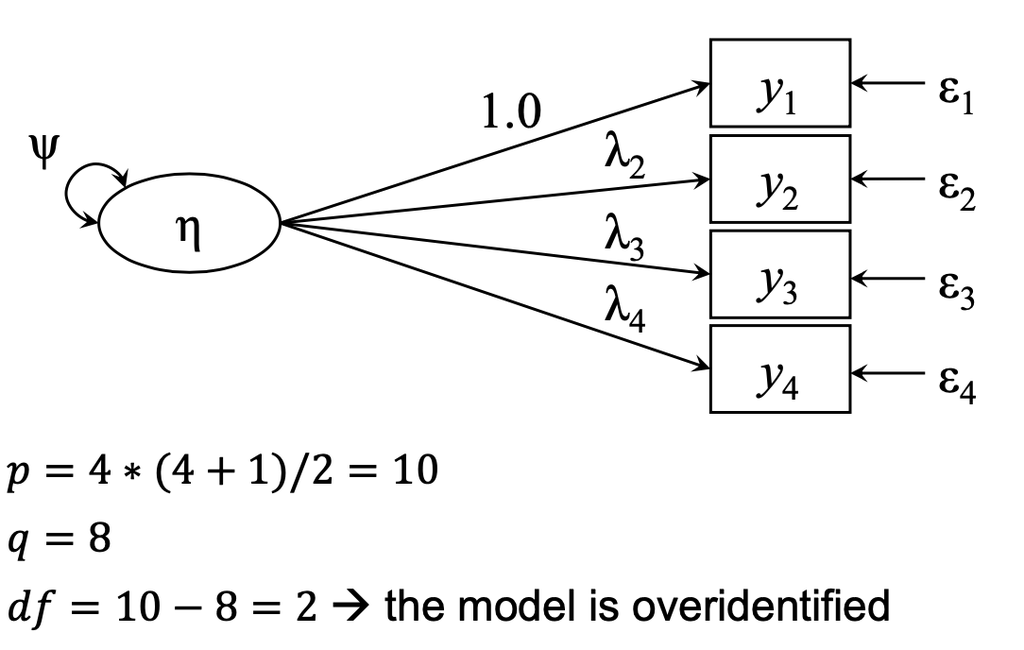

With df > 0 we can test the fit of the estimated model to the empirical data

The maximum likelihood function minimizes the discrepancy between observed and model implied (co)variances

$$F_{ML}=ln|\Sigma(\theta)|-ln|S|+tr[S\Sigma(\theta)^{-1}]-p$$

The final value of the discrepancy function $F_{ML}$ multiplied with n – 1 follows a $\chi^2$ distribution:

$$F_{ML}(n-1)=\chi^2_{ML}$$

### Step 6

**Checking the fit measurements**

Global fit measures: appropriateness of the entire model

- Absolute Goodness/Badness-of-fit Indices
  - Relation between $\chi^2$ and degrees of freedom = $\chi^2/df$ - (**joreskog_general_1969?**)
  - Discrepancy to a saturated model = RMSEA - (**steiger_notes_2016?**))
  - Discrepancy due to overall error = SRMR - Bentler (1995)
- Comparative Goodness-of-fit Indices
  - Comparison to a null model = CFI - (**bentler_comparative_1990?**), TLI - (**tucker_reliability_1973?**)
- Detailed fit measures: appropriateness of specific parts of the model (e.g., constraints)
  - LRT
  - Modification indices
  - Residual matrices

| Index | Typ | Theoretical range | Cut-off | N sensitive | Penalty for complexity |
| --- | --- | --- | --- | --- | --- |
| X2/df | badness | $\ge 0$ | $<5$ | yes | no |
| CFI | godness | 0.0 – 1.0 | $\ge.95\ (\ge.90)$ | no | yes |
| TLI | godness | 0.0 – 1.0* | / | no | yes |
| SRMR | badness | $\ge 0$ | $<.08$ | yes | no |
| RMSEA | badness | $\ge 0$ | $\leq.05\ (\leq.08)$ | yes to small N | yes |
| PCLOSE | badness | 0.0 – 1.0 | $\ge.95$ | yes | / |

*negative values indicate extremely misspecified model; when exceeds 1, model is extremely well-fitting

*Source: West et al. (2012). Model fit and model selection in structural equation modeling. In Hoyle, R. H. (Ed.). (2012). Handbook of Structural Equation Modeling (p. 212-213). Guilford Press. See also (**hu_cutoff_1999?**).*

### Step 7

**Checking for misspecification**

What causes model misfit?

- Indicator choice
- Factor choice
- Violations of assumptions (e.g., multivariate normality)
- Causal structure (e.g., restrictions)

How to diagnose model misfit?

- Parameter estimates (Heywood cases?)
- Residual matrices (i.e., differences between observed and estimated covariances)
- Modification indices (approximation of the reduction of chi-square if a single constrained parameter is freely estimated)

Modification indices (MIs):

Lagrange multiplier ((**sorbom_model_1989?**)) - approximation of the reduction of $\chi^2$ if a single constrained parameter is freely estimated

- Test of local fit
- One parameter at a time

Constrained parameters in CFA:

- Factor cross-loadings
- Residual correlations

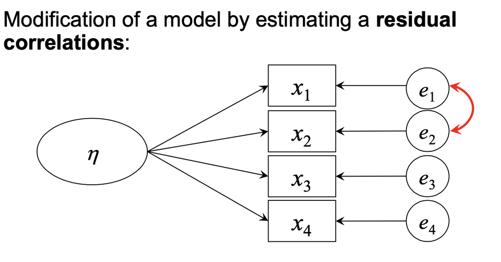

- Some of the covariation of e1 and e2 is due to sources other than the common factor
- Reasons: method effects, item wording, acquiescence, social desirability, unaccounted theoretical common causes

### Step 8

**Identifying the mean structure (optional)**

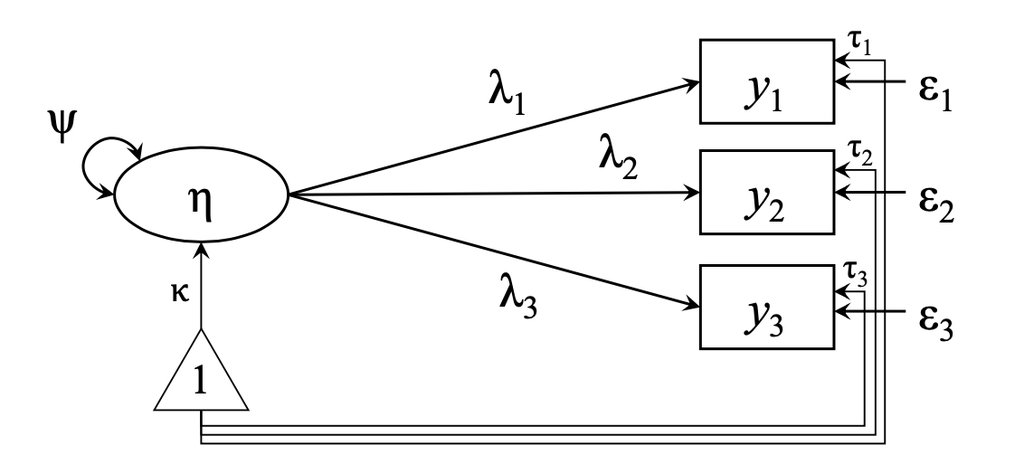

The formal expression including item intercepts:

$$\begin{split}
y_1=\tau_1+\lambda_1\eta+\epsilon_1 \\
y_2=\tau_2+\lambda_2\eta+\epsilon_2 \\
y_3=\tau_3+\lambda_3\eta+\epsilon_3 \\
\end{split}$$

Means of the indicators can be reproduced by the intercept, factor loading, and latent mean estimates

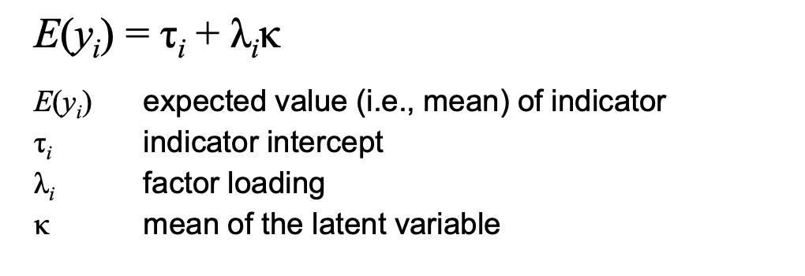

Identifying the mean structure:

- Fixing the intercept of the reference indicator to zero
- Fixing the latent mean to zero

## CFA - Universalism

### Step 1

Our example measurement model Universalism comes from the Theory of Basic Human Values according to Schwartz (1992) and comprises three facets - Concern, Nature, Tolerance.

Concern: Commitment to equality, justice and protection for all people

Nature: Preservation of the natural environment

Tolerance: Acceptance and understanding of those who are different from oneself

In order to measure this attitude construct, three questions (items) were created in ESS 7 (2014) and queried in various countries (e.g. Czech Republic, Germany, Great Britain).

| Name | Label | Construct |
| --- | --- | --- |
| ipeqopt | Important that people are treated equally and have equal opportunities | Universalism |
| ipudrst | Important to understand different people | Universalism |
| impenv | Important to care for nature and environment | Universalism |

### Step 2

Indicators are “effects” of the latent variable and therefore we specify a reflective measurement model

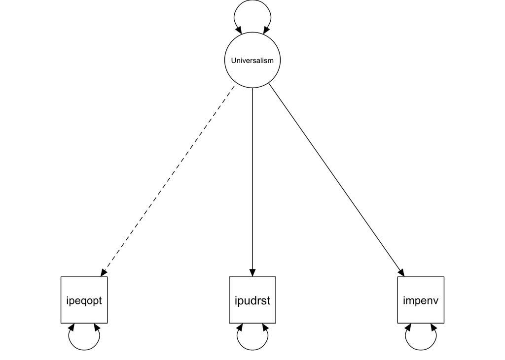

### Step 3

The syntax commands for specifying a lavaan model:

https://lavaan.ugent.be/tutorial/syntax1.html

| Formula type | Operator | Mnemonic |
| --- | --- | --- |
| latent variable definition | =~ | is measured by |
| regression | ~ | is regressed on |
| (residual) (co)variance | ~~ | is correlated with |
| intercept | ~1 | intercept |

```r
universalism <- "Universalism =~ ipeqopt + ipudrst + impenv"
```

Lavaan automatically uses the reference indicator method, so one indicator’s factual loading is fixed at 1. Accordingly, the variance of the latent factor is estimated.

In Lavaan, however, it is also very easy to use the fixed factor method, i.e. to fix the variance of the latent factor to 1. This allows all factor loadings to be freely estimated.

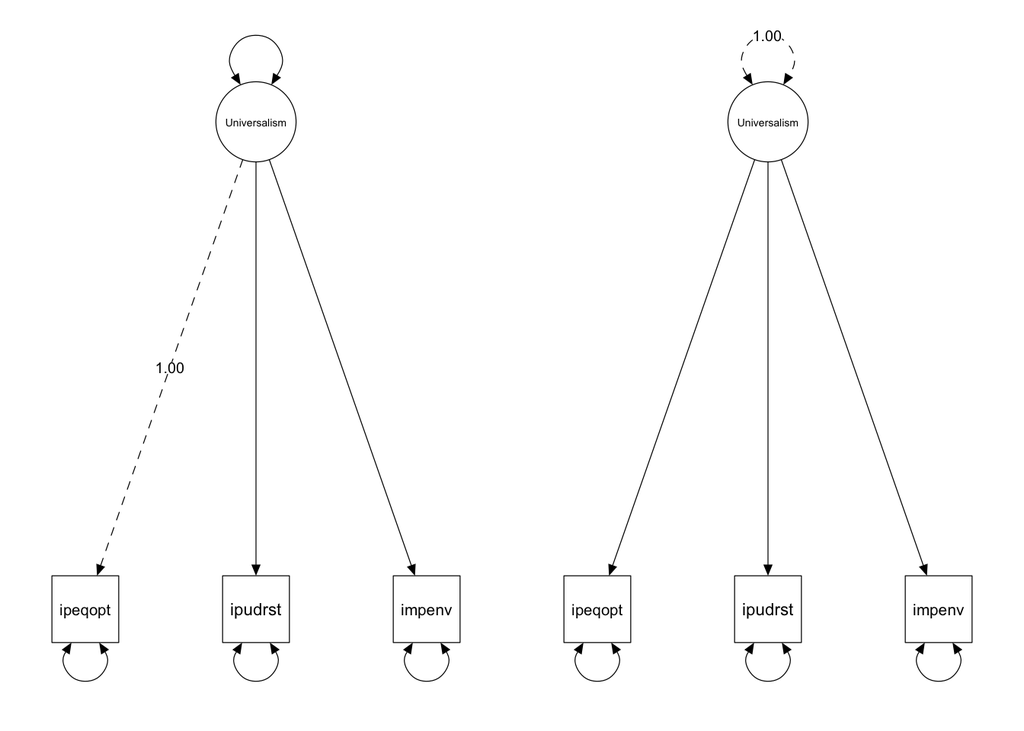

This requires the use of labels, i.e. the labeling of individual parameters in order to be able to control them directly. The syntax commands for labeling a lavaan model can be found here: https://lavaan.ugent.be/tutorial/syntax2.html. For this step, we only need to understand how individual parameters can be fixed and freely calculated. As soon as it comes to the calculation of measurement invariance, we will work with labels again. But more on that later.

Reference indicator method:

```r
universalism <- "Universalism =~ 1*ipeqopt + ipudrst + impenv"
```

Fixed factor method:

```r
universalism <- "
# specification of the measurement model
Universalism =~ NA*ipeqopt + ipudrst + impenv

# specification of the variance
Universalism ~~ 1*Universalism
"
```

Freely estimate the factor loading of the first indicator by NA*ipeqopt and fix the variance of the latent factor by 1*Universalism The variance of a variable is specified as covariance with itself, hence Universalism ~~ Universalism In the end we get Universalism ~~ 1*Universalism

### Step 4

Now let’s get an overview of the properties of our variables. First, let’s look at the descriptive statistics of our items to gain knowledge of missing values, central tendency properties, variability, and distribution.

It is possible to choose between:

Mardia’s test (“mardia”), Henze-Zirkler’s test (“hz”), Royston’s test (“royston”), Doornik-Hansen’s test (“dh”) and E-statistic (“energy”). Default is Henze-Zirkler’s test.

```r
ESS07 %>%
  select(ipeqopt, ipudrst, impenv) %>%
  mvn() %>%
  # optional for better display
  export_table(table_width = 1, digits = 3)
```

```
Test          |      HZ | p value | MVN
---------------------------------------
Henze-Zirkler | 133.042 |       0 |  NO

Test             |  Variable | Statistic |   p value | Normality
----------------------------------------------------------------
Anderson-Darling |  ipeqopt  |  362.6880 |  <0.001   |    NO
Anderson-Darling |  ipudrst  |  332.9049 |  <0.001   |    NO
Anderson-Darling |  impenv   |  322.7889 |  <0.001   |    NO

   n |  Mean | Std.Dev | Median | Min | Max | 25th | 75th |   Skew | Kurtosis
-----------------------------------------------------------------------------
5844 | 4.945 |   1.040 |      5 |   1 |   6 |    4 |    6 | -1.142 |    1.295
5844 | 4.717 |   1.027 |      5 |   1 |   6 |    4 |    5 | -0.937 |    0.892
5844 | 4.878 |   1.025 |      5 |   1 |   6 |    4 |    6 | -0.933 |    0.732
```

We can also validate this finding graphically.

The Q-Q plot, where “Q” stands for quantile, is a widely used graphical approach to evaluate the agreement between two probability distributions. Each axis refers to the quantiles of probability distributions to be compared, where one of the axes indicates theoretical quantiles (hypothesized quantiles) and the other indicates the observed quantiles. If the observed data fit hypothesized distribution, the points in the Q-Q plot will approximately lie on the line y = x.

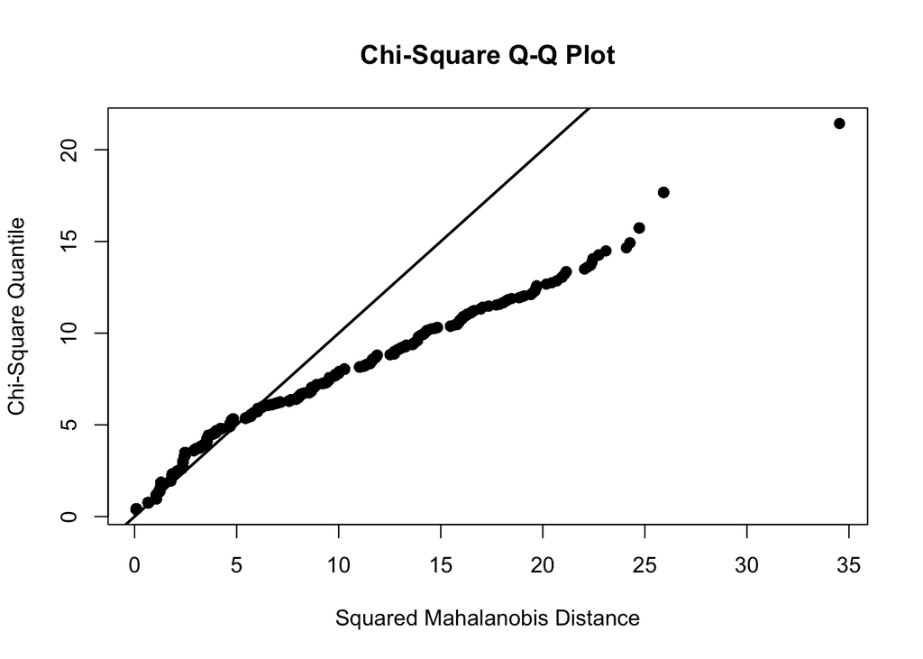

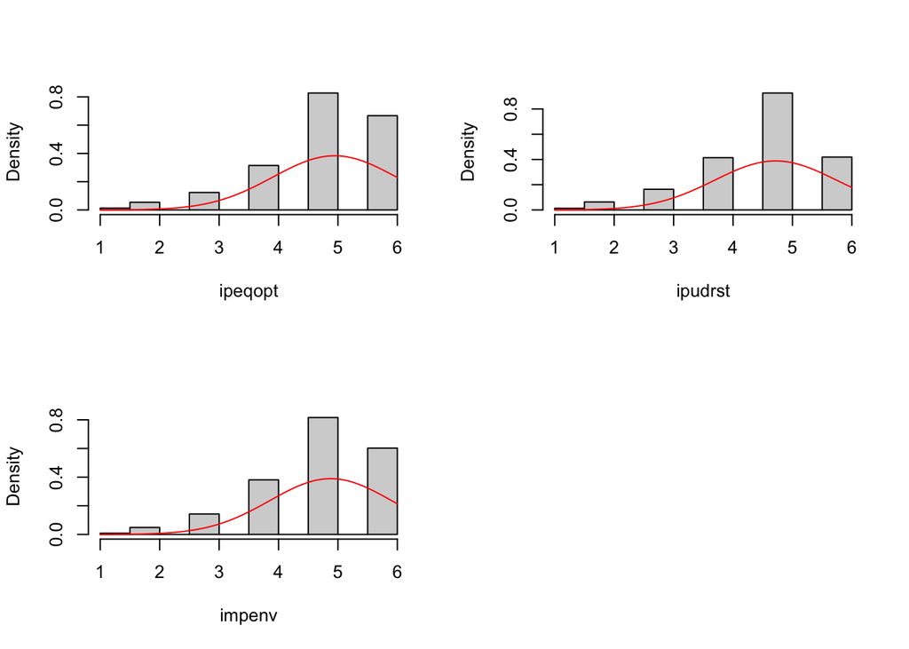

```r
plots <- ESS07 %>%
  select(ipeqopt, ipudrst, impenv) %>%
  mvn(univariatePlot = "histogram", multivariatePlot = "qq")
```

As a result, we can conclude that this data set does not satisfy MVN assumption based on the fact that the two test results are against it and the chi-square Q-Q plot indicates departures from multivariate normal distribution.

**Due to the missing multivariate normal distribution, we use the MLR estimator. If we were dealing with missing values, we would use Full Information Maximum Likelihood (FIML) as the estimation strategy.**

Next, we want to check whether the items are sufficiently correlated with each other. A sufficient correlation of the items would support our assumption of a reflective factor, since it would be reasonable that the common variance of the variables is caused by the latent factor.

```r
ESS07 %>%
  select(ipeqopt, ipudrst, impenv) %>%
  correlation() %>%
  summary() %>%
  # optional for better display
  export_table(table_width = 1, digits = 2)
```

```
Parameter | impenv | ipudrst
----------------------------
ipeqopt   |   0.28 |    0.35
ipudrst   |   0.30 |
```

There is sufficient correlation, so it is initially plausible that a latent factor in the background would explain the common variance.

Finally, we want to deal with the anticipated itemscale. Here we are primarily interested in the various measures of internal consistencies.

```r
ESS07 %>%
  select(ipeqopt, ipudrst, impenv) %>%
  principal_components(n = 1) %>%
  check_itemscale() %>%
  # optional for better display
  export_table(table_width = 1, digits = 2)
```

```
Item    | Missings | Mean |   SD | Skewness | Difficulty | Discrimination | alpha if deleted
--------------------------------------------------------------------------------------------
ipeqopt |        0 | 4.95 | 1.04 |    -1.14 |       0.82 |           0.39 |             0.46
ipudrst |        0 | 4.72 | 1.03 |    -0.94 |       0.79 |           0.41 |             0.43
impenv  |        0 | 4.88 | 1.02 |    -0.93 |       0.81 |           0.35 |             0.52
```

- Item difficulty should range between 0.2 and 0.8. Ideal value is p+(1-p)/2 (which mostly is between 0.5 and 0.8). Lower values are a signal for more difficult items, while higher values close to one are a sign for easier items. The ideal value for item difficulty is p + (1 - p) / 2, where p = 1 / max(x). In most cases, the ideal item difficulty lies between 0.5 and 0.8.
- For item discrimination, acceptable values are 0.20 or higher; the closer to 1.00 the better. The absolute value of the item discrimination indices should be above 0.1. An index between 0.1 and 0.3 is considered as “fair”, while an index above 0.3 (or below -0.3) is “good”. Items with low discrimination indices are often ambiguously worded and should be examined. Items with negative indices should be examined to determine why a negative value was obtained (e.g. reversed answer categories regarding positive and negative poles).
- Mean inter-item-correlation is an alternative measure to indicate acceptability. Satisfactory range lies between 0.2 and 0.4. “Ideally, the average inter-item correlation for a set of items should be between .20 and .40, suggesting that while the items are reasonably homogenous, they do contain sufficiently unique variance so as to not be isomorphic with each other. When values are lower than .20, then the items may not be representative of the same content domain. If values are higher than .40, the items may be only capturing a small bandwidth of the construct.” (**michalos_inter-item_2014?**)

The selected items can be plausibly mapped together in one scale.

### Step 5

Now let’s estimate the model using Lavaan. For this we use the cfa() function.

```r
universalism_fit <- cfa(
  model = "Universalism =~ ipeqopt + ipudrst + impenv",
  data = ESS07,
  estimator = "MLR",
  # optional if there are missing values
  missing = "fiml.x"
)
```

Now we can look at the estimated model. To do this, we use the summary() function.

- fit.measures = T - shows us the most important fit measurements of our model
- standardized = T - shows us standardized values in the output
- rsquare = T - shows us the explained variance of the dependent variables

```r
summary(
  object = universalism_fit,
  fit.measures = T,
  standardized = T,
  rsquare = T
)
```

```
lavaan 0.6-12 ended normally after 24 iterations

  Estimator                                         ML
  Optimization method                           NLMINB
  Number of model parameters                         9

  Number of observations                          5844
  Number of missing patterns                         1

Model Test User Model:
                                              Standard      Robust
  Test Statistic                                 0.000       0.000
  Degrees of freedom                                 0           0

Model Test Baseline Model:

  Test statistic                              1532.717    1023.100
  Degrees of freedom                                 3           3
  P-value                                        0.000       0.000
  Scaling correction factor                                  1.498

User Model versus Baseline Model:

  Comparative Fit Index (CFI)                    1.000       1.000
  Tucker-Lewis Index (TLI)                       1.000       1.000

  Robust Comparative Fit Index (CFI)                            NA
  Robust Tucker-Lewis Index (TLI)                               NA

Loglikelihood and Information Criteria:

  Loglikelihood user model (H0)             -24640.784  -24640.784
  Loglikelihood unrestricted model (H1)     -24640.784  -24640.784

  Akaike (AIC)                               49299.567   49299.567
  Bayesian (BIC)                             49359.626   49359.626
  Sample-size adjusted Bayesian (BIC)        49331.026   49331.026

Root Mean Square Error of Approximation:

```

[output cut: 30 more lines]

```
   .impenv            4.878    0.013  363.981    0.000    4.878    4.761
    Universalism      0.000                               0.000    0.000

Variances:
                   Estimate  Std.Err  z-value  P(>|z|)   Std.lv  Std.all
   .ipeqopt           0.729    0.030   24.070    0.000    0.729    0.673
   .ipudrst           0.659    0.029   22.371    0.000    0.659    0.624
   .impenv            0.802    0.023   34.294    0.000    0.802    0.764
    Universalism      0.354    0.027   13.341    0.000    1.000    1.000

R-Square:
                   Estimate
    ipeqopt           0.327
    ipudrst           0.376
    impenv            0.236
```

Since we estimated a model with three indicators, it is a saturated model, i.e. a model identified with 0 degrees of freedom.

This allows the following graphic to be created with standardized factor loadings.

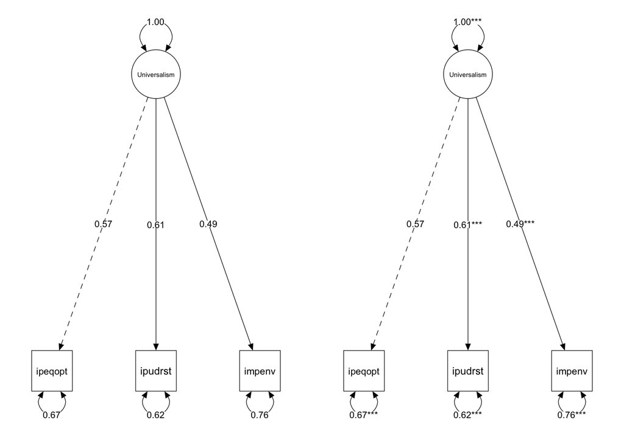

```r
# optional for better display
par(mfrow=c(1,2))

universalism_plot <- universalism_fit %>%
  semPaths(
    whatLabels = "std",
    style = "mx",
    layout = "tree",
    edge.color = "black",
    intercepts = F,
    sizeMan = 10,
    sizeLat = 12,
    edge.label.cex = 1,
    nCharNodes = 50
  )

universalism_plot %>%
  mark_sig(universalism_fit) %>%
  plot()
```

The semptools package also allows us to easily add additional information to our graphics ( https://cran.r-project.org/web/packages/semptools/vignettes/semptools.html). Here I have also included the level of statistical significance.

### Step 6

A look at the fit measures shows us that the model is saturated due to the 0 degrees of freedom and thus achieves a perfect data fit.

### Step 7

In the following we want to check whether the selected items represent a factor. It can be seen that the factor loadings all reach the cut off of $\ge$ 0.4 and thus, in combination with the fit indices, there is an appropriate measurement model.

If there are recognizable misfits, we can access the modification indices.

Accordingly, there are no modification options, since the model has just been identified and no degrees of freedom are available.

So let’s look at two more models of Theory of Basic Human Values from the ESS07.

## CFA - Tradition/Conformity

### Step 1

Tradition: Maintaining and preserving cultural, family or religious traditions

Conformity-Interpersonal: Avoidance of upsetting or harming other people

Conformity-Rules: Compliance with rules, laws, and formal obligations

[output not shown]

### Step 2

Indicators are “effects” of the latent variable and therefore we specify a reflective measurement model.

### Step 3

We use the reference indicator method again to calculate the model.

### Step 4

```r
ESS07 %>%
  select(ipmodst, imptrad, ipfrule, ipbhprp) %>%
  mvn() %>%
  # optional
  export_table(table_width = 1, digits = 3)
```

```
Test          |     HZ | p value | MVN
--------------------------------------
Henze-Zirkler | 20.393 |       0 |  NO

Test             |  Variable | Statistic |   p value | Normality
----------------------------------------------------------------
Anderson-Darling |  ipmodst  |  242.6587 |  <0.001   |    NO
Anderson-Darling |  imptrad  |  202.8157 |  <0.001   |    NO
Anderson-Darling |  ipfrule  |  173.6286 |  <0.001   |    NO
Anderson-Darling |  ipbhprp  |  227.9644 |  <0.001   |    NO

   n |  Mean | Std.Dev | Median | Min | Max | 25th | 75th |   Skew | Kurtosis
-----------------------------------------------------------------------------
5844 | 4.344 |   1.208 |      5 |   1 |   6 |    4 |    5 | -0.643 |   -0.191
5844 | 4.155 |   1.380 |      4 |   1 |   6 |    3 |    5 | -0.529 |   -0.601
5844 | 3.700 |   1.393 |      4 |   1 |   6 |    2 |    5 | -0.161 |   -0.984
5844 | 4.258 |   1.281 |      5 |   1 |   6 |    3 |    5 | -0.554 |   -0.514
```

```r
ESS07 %>%
  select(ipmodst, imptrad, ipfrule, ipbhprp) %>%
  correlation() %>%
  summary() %>%
  # optional for better display
  export_table(table_width = 1, digits = 2)
```

```
Parameter | ipbhprp | ipfrule | imptrad
---------------------------------------
ipmodst   |    0.26 |    0.18 |    0.16
imptrad   |    0.32 |    0.29 |
ipfrule   |    0.40 |         |
```

There is sufficient correlation, so it is initially plausible that a latent factor in the background would explain the common variance.

```r
ESS07 %>%
  select(ipmodst, imptrad, ipfrule, ipbhprp) %>%
  principal_components(n = 1) %>%
  check_itemscale() %>%
  # optional for better display
  export_table(table_width = 1, digits = 2)
```

```
Item    | Missings | Mean |   SD | Skewness | Difficulty | Discrimination | alpha if deleted
--------------------------------------------------------------------------------------------
ipmodst |        0 | 4.34 | 1.21 |    -0.64 |       0.72 |           0.27 |             0.60
imptrad |        0 | 4.16 | 1.38 |    -0.53 |       0.69 |           0.36 |             0.54
ipfrule |        0 | 3.70 | 1.39 |    -0.16 |       0.62 |           0.41 |             0.50
ipbhprp |        0 | 4.26 | 1.28 |    -0.55 |       0.71 |           0.48 |             0.45
```

The selected items can be plausibly mapped together in one scale.

### Step 5

```r
tradition_conformity_fit <- cfa(
  model = "TraditionConformity =~ ipmodst + imptrad + ipfrule + ipbhprp",
  data = ESS07,
  estimator = "MLR",
  # optional if there are missing values
  missing = "fiml.x"
)
```

```r
summary(
  object = tradition_conformity_fit,
  fit.measures = T,
  standardized = T
  # rsquare = T
)
```

```
lavaan 0.6-12 ended normally after 31 iterations

  Estimator                                         ML
  Optimization method                           NLMINB
  Number of model parameters                        12

  Number of observations                          5844
  Number of missing patterns                         1

Model Test User Model:
                                              Standard      Robust
  Test Statistic                                17.439      14.378
  Degrees of freedom                                 2           2
  P-value (Chi-square)                           0.000       0.001
  Scaling correction factor                                  1.213
    Yuan-Bentler correction (Mplus variant)

Model Test Baseline Model:

  Test statistic                              2339.880    1848.011
  Degrees of freedom                                 6           6
  P-value                                        0.000       0.000
  Scaling correction factor                                  1.266

User Model versus Baseline Model:

  Comparative Fit Index (CFI)                    0.993       0.993
  Tucker-Lewis Index (TLI)                       0.980       0.980

  Robust Comparative Fit Index (CFI)                         0.994
  Robust Tucker-Lewis Index (TLI)                            0.981

Loglikelihood and Information Criteria:

  Loglikelihood user model (H0)             -38377.968  -38377.968
  Scaling correction factor                                  1.002
      for the MLR correction
  Loglikelihood unrestricted model (H1)     -38369.248  -38369.248
  Scaling correction factor                                  1.032
      for the MLR correction
```

[output cut: 34 more lines]

```
Intercepts:
                   Estimate  Std.Err  z-value  P(>|z|)   Std.lv  Std.all
   .ipmodst           4.344    0.016  274.875    0.000    4.344    3.596
   .imptrad           4.155    0.018  230.189    0.000    4.155    3.011
   .ipfrule           3.700    0.018  203.091    0.000    3.700    2.657
   .ipbhprp           4.258    0.017  254.054    0.000    4.258    3.323
    TraditnCnfrmty    0.000                               0.000    0.000

Variances:
                   Estimate  Std.Err  z-value  P(>|z|)   Std.lv  Std.all
   .ipmodst           1.278    0.027   48.093    0.000    1.278    0.876
   .imptrad           1.470    0.036   41.297    0.000    1.470    0.772
   .ipfrule           1.301    0.038   34.612    0.000    1.301    0.671
   .ipbhprp           0.853    0.039   21.855    0.000    0.853    0.519
    TraditnCnfrmty    0.182    0.018   10.217    0.000    1.000    1.000
```

The model is identified with two degrees of freedom.

### Step 7

In this model, the factor loading of the item ipmodst is clearly misfit, since the factor loading cut-off of 0.4 is not reached.

Here it has to be considered whether the item has a value for the construct or whether the item has to be removed from the measurement model. We decide to take it out.

Further modifications are not necessary since the model shows a very good fit to the data.

```r
tradition_conformity_fit2 <- cfa(
  model = "TraditionConformity =~ imptrad + ipfrule + ipbhprp",
  data = ESS07,
  estimator = "MLR",
  # optional if there are missing values
  missing = "fiml.x"
)
```

```r
summary(
  object = tradition_conformity_fit2,
  fit.measures = T,
  standardized = T
  # rsquare = T
)
```

```
lavaan 0.6-12 ended normally after 28 iterations

  Estimator                                         ML
  Optimization method                           NLMINB
  Number of model parameters                         9

  Number of observations                          5844
  Number of missing patterns                         1

Model Test User Model:
                                              Standard      Robust
  Test Statistic                                 0.000       0.000
  Degrees of freedom                                 0           0

Model Test Baseline Model:

  Test statistic                              1849.694    1427.618
  Degrees of freedom                                 3           3
  P-value                                        0.000       0.000
  Scaling correction factor                                  1.296

User Model versus Baseline Model:

  Comparative Fit Index (CFI)                    1.000       1.000
  Tucker-Lewis Index (TLI)                       1.000       1.000

  Robust Comparative Fit Index (CFI)                         1.000
  Robust Tucker-Lewis Index (TLI)                            1.000

Loglikelihood and Information Criteria:

  Loglikelihood user model (H0)             -29217.708  -29217.708
  Loglikelihood unrestricted model (H1)     -29217.708  -29217.708

  Akaike (AIC)                               58453.417   58453.417
  Bayesian (BIC)                             58513.475   58513.475
  Sample-size adjusted Bayesian (BIC)        58484.876   58484.876

Root Mean Square Error of Approximation:

```

[output cut: 24 more lines]

```
    ipbhprp                 1.252    0.061   20.475    0.000    0.842    0.658

Intercepts:
                   Estimate  Std.Err  z-value  P(>|z|)   Std.lv  Std.all
   .imptrad           4.155    0.018  230.189    0.000    4.155    3.011
   .ipfrule           3.700    0.018  203.091    0.000    3.700    2.657
   .ipbhprp           4.258    0.017  254.054    0.000    4.258    3.323
    TraditnCnfrmty    0.000                               0.000    0.000

Variances:
                   Estimate  Std.Err  z-value  P(>|z|)   Std.lv  Std.all
   .imptrad           1.452    0.036   39.882    0.000    1.452    0.762
   .ipfrule           1.236    0.043   29.051    0.000    1.236    0.637
   .ipbhprp           0.932    0.040   23.156    0.000    0.932    0.568
    TraditnCnfrmty    0.453    0.032   14.009    0.000    1.000    1.000
```

This makes the measurement model suitable for further use.

## CFA - Perceived Threat

### Step 1

| Name | Label | Construct |
| --- | --- | --- |
| imbgeco | Immigration bad or good for country’s economy | Perceived threat |
| imueclt | Country’s cultural life undermined or enriched by immigrants | Perceived threat |
| imtcjob | Immigrants take jobs away in country or create new jobs | Perceived threat |
| rlgueim | Religious beliefs and practices undermined or enriched by immigrants | Perceived threat |

### Step 2

Indicators are “effects” of the latent variable and therefore we specify a reflective measurement model

### Step 3

We use the reference indicator method again to calculate the model.

### Step 4

```r
ESS07 %>%
  select(imbgeco, imueclt, imtcjob, rlgueim) %>%
  mvn() %>%
  # optional for better display
  export_table(table_width = 1, digits = 3)
```

```
Test          |     HZ | p value | MVN
--------------------------------------
Henze-Zirkler | 17.085 |       0 |  NO

Test             |  Variable | Statistic |   p value | Normality
----------------------------------------------------------------
Anderson-Darling |  imbgeco  |   61.6271 |  <0.001   |    NO
Anderson-Darling |  imueclt  |   53.8325 |  <0.001   |    NO
Anderson-Darling |  imtcjob  |  103.8354 |  <0.001   |    NO
Anderson-Darling |  rlgueim  |  108.6560 |  <0.001   |    NO

   n |  Mean | Std.Dev | Median | Min | Max | 25th | 75th |  Skew | Kurtosis
----------------------------------------------------------------------------
5844 | 4.979 |   2.466 |      5 |   0 |  10 |    3 |    7 | 0.186 |   -0.521
5844 | 4.696 |   2.577 |      5 |   0 |  10 |    3 |    6 | 0.174 |   -0.623
5844 | 5.187 |   2.301 |      5 |   0 |  10 |    4 |    7 | 0.228 |   -0.165
5844 | 5.318 |   2.188 |      5 |   0 |  10 |    4 |    7 | 0.041 |    0.053
```

The variables are scaled metrically on a scale from 0 to 10. Nevertheless, there is neither a univariate nor a multivariate normal distribution.

```r
ESS07 %>%
  select(imbgeco, imueclt, imtcjob, rlgueim) %>%
  correlation() %>%
  summary() %>%
  # optional for better display
  export_table(table_width = 1, digits = 2)
```

```
Parameter | rlgueim | imtcjob | imueclt
---------------------------------------
imbgeco   |    0.44 |    0.59 |    0.67
imueclt   |    0.57 |    0.54 |
imtcjob   |    0.41 |         |
```

There is sufficient correlation, so it is initially plausible that a latent factor in the background would explain the common variance.

```r
ESS07 %>%
  select(imbgeco, imueclt, imtcjob, rlgueim) %>%
  principal_components(n = 1) %>%
  check_itemscale() %>%
  # optional for better display
  export_table(table_width = 1, digits = 2)
```

```
Item    | Missings | Mean |   SD | Skewness | Difficulty | Discrimination | alpha if deleted
--------------------------------------------------------------------------------------------
imbgeco |        0 | 4.98 | 2.47 |     0.19 |       0.50 |           0.70 |             0.76
imueclt |        0 | 4.70 | 2.58 |     0.17 |       0.47 |           0.73 |             0.74
imtcjob |        0 | 5.19 | 2.30 |     0.23 |       0.52 |           0.61 |             0.79
rlgueim |        0 | 5.32 | 2.19 |     0.04 |       0.53 |           0.56 |             0.82
```

The selected items can be plausibly mapped together in one scale.

### Step 5

```r
perceived_threat_fit <- cfa(
  model = "PerceivedThreat =~ imbgeco + imueclt + imtcjob + rlgueim",
  data = ESS07,
  estimator = "MLR",
  # optional if there are missing values
  missing = "fiml.x"
)
```

```r
summary(
  object = perceived_threat_fit,
  fit.measures = T,
  standardized = T
  # rsquare = T
)
```

```
lavaan 0.6-12 ended normally after 27 iterations

  Estimator                                         ML
  Optimization method                           NLMINB
  Number of model parameters                        12

  Number of observations                          5844
  Number of missing patterns                         1

Model Test User Model:
                                              Standard      Robust
  Test Statistic                               279.766     184.727
  Degrees of freedom                                 2           2
  P-value (Chi-square)                           0.000       0.000
  Scaling correction factor                                  1.514
    Yuan-Bentler correction (Mplus variant)

Model Test Baseline Model:

  Test statistic                              8797.948    5161.721
  Degrees of freedom                                 6           6
  P-value                                        0.000       0.000
  Scaling correction factor                                  1.704

User Model versus Baseline Model:

  Comparative Fit Index (CFI)                    0.968       0.965
  Tucker-Lewis Index (TLI)                       0.905       0.894

  Robust Comparative Fit Index (CFI)                         0.969
  Robust Tucker-Lewis Index (TLI)                            0.906

Loglikelihood and Information Criteria:

  Loglikelihood user model (H0)             -49161.345  -49161.345
  Scaling correction factor                                  1.214
      for the MLR correction
  Loglikelihood unrestricted model (H1)     -49021.462  -49021.462
  Scaling correction factor                                  1.257
      for the MLR correction
```

[output cut: 34 more lines]

```
Intercepts:
                   Estimate  Std.Err  z-value  P(>|z|)   Std.lv  Std.all
   .imbgeco           4.979    0.032  154.352    0.000    4.979    2.019
   .imueclt           4.696    0.034  139.327    0.000    4.696    1.823
   .imtcjob           5.187    0.030  172.337    0.000    5.187    2.254
   .rlgueim           5.318    0.029  185.807    0.000    5.318    2.431
    PerceivedThret    0.000                               0.000    0.000

Variances:
                   Estimate  Std.Err  z-value  P(>|z|)   Std.lv  Std.all
   .imbgeco           2.211    0.085   26.148    0.000    2.211    0.364
   .imueclt           1.913    0.094   20.355    0.000    1.913    0.288
   .imtcjob           2.865    0.087   33.077    0.000    2.865    0.541
   .rlgueim           2.933    0.080   36.474    0.000    2.933    0.613
    PerceivedThret    3.870    0.119   32.528    0.000    1.000    1.000
```

The model is identified with two degrees of freedom.

### Step 6

The model shows a clear misspecification by the RMSEA index.

### Step 7

The factor loadings all show sufficient loading. So we can immediately devote ourselves to the modification indices in order to understand the misspecification evident in the RMSEA.

```r
perceived_threat_fit %>%
  modificationindices(standardized = T, sort. = T)
```

```
       lhs op     rhs      mi    epc sepc.lv sepc.all sepc.nox
19 imueclt ~~ rlgueim 238.993  0.877   0.877    0.370    0.370
16 imbgeco ~~ imtcjob 238.993  0.909   0.909    0.361    0.361
17 imbgeco ~~ rlgueim 207.425 -0.747  -0.747   -0.293   -0.293
18 imueclt ~~ imtcjob 207.424 -0.945  -0.945   -0.403   -0.403
20 imtcjob ~~ rlgueim   1.848 -0.063  -0.063   -0.022   -0.022
15 imbgeco ~~ imueclt   1.848 -0.127  -0.127   -0.062   -0.062
```

- Column op indicates the operator or type of parameter
- Column mi contains the modification indices
- Column epc contains the expected parameter change if the parameter was estimated

The modification indices tell us that adjusting the residual covariance between items imueclt and rlgueim would have the largest effect on model fitting (in terms of the chi-square test statistic).

This is because some of the covariation of imueclt and rlgueim is due to sources other than the common factor.

Reasons: method effects, item wording, acquiescence, social desirability, unaccounted theoretical common causes.

We then modify our initial model and remove the residual covariance constraint between the two items, which is fixed at 0, and let it calculate freely.

```r
perceived_threat_fit2 <- cfa(
  model = "
  PerceivedThreat =~ imbgeco + imueclt + imtcjob + rlgueim

  imueclt   ~~  rlgueim
  ",
  data = ESS07,
  estimator = "MLR",
  # optional if there are missing values
  missing = "fiml.x"
)
```

```r
summary(
  object = perceived_threat_fit2,
  fit.measures = T,
  standardized = T
  # rsquare = T
)
```

```
lavaan 0.6-12 ended normally after 31 iterations

  Estimator                                         ML
  Optimization method                           NLMINB
  Number of model parameters                        13

  Number of observations                          5844
  Number of missing patterns                         1

Model Test User Model:
                                              Standard      Robust
  Test Statistic                                47.224      31.440
  Degrees of freedom                                 1           1
  P-value (Chi-square)                           0.000       0.000
  Scaling correction factor                                  1.502
    Yuan-Bentler correction (Mplus variant)

Model Test Baseline Model:

  Test statistic                              8797.948    5161.721
  Degrees of freedom                                 6           6
  P-value                                        0.000       0.000
  Scaling correction factor                                  1.704

User Model versus Baseline Model:

  Comparative Fit Index (CFI)                    0.995       0.994
  Tucker-Lewis Index (TLI)                       0.968       0.965

  Robust Comparative Fit Index (CFI)                         0.995
  Robust Tucker-Lewis Index (TLI)                            0.969

Loglikelihood and Information Criteria:

  Loglikelihood user model (H0)             -49045.074  -49045.074
  Scaling correction factor                                  1.238
      for the MLR correction
  Loglikelihood unrestricted model (H1)     -49021.462  -49021.462
  Scaling correction factor                                  1.257
      for the MLR correction
```

[output cut: 39 more lines]

```
Intercepts:
                   Estimate  Std.Err  z-value  P(>|z|)   Std.lv  Std.all
   .imbgeco           4.979    0.032  154.352    0.000    4.979    2.019
   .imueclt           4.696    0.034  139.327    0.000    4.696    1.823
   .imtcjob           5.187    0.030  172.337    0.000    5.187    2.254
   .rlgueim           5.318    0.029  185.807    0.000    5.318    2.431
    PerceivedThret    0.000                               0.000    0.000

Variances:
                   Estimate  Std.Err  z-value  P(>|z|)   Std.lv  Std.all
   .imbgeco           1.673    0.091   18.481    0.000    1.673    0.275
   .imueclt           2.551    0.097   26.176    0.000    2.551    0.384
   .imtcjob           2.747    0.084   32.790    0.000    2.747    0.519
   .rlgueim           3.409    0.086   39.542    0.000    3.409    0.712
    PerceivedThret    4.408    0.126   34.979    0.000    1.000    1.000
```

The RMSEA is then back in our anticipated cut-off area and we can continue working with the measurement model.

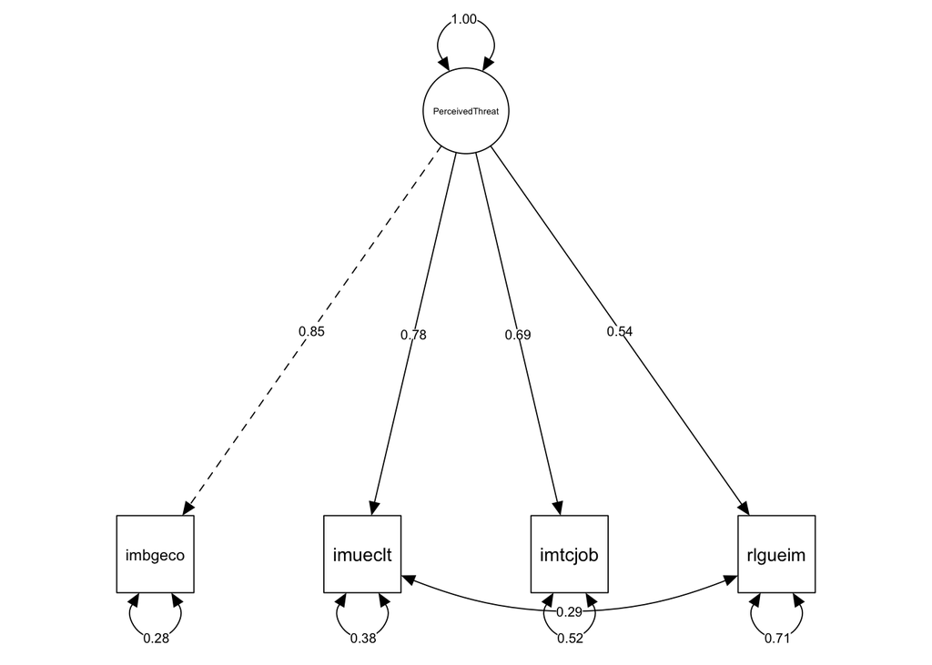

```r
perceived_threat_fit2 %>%
  semPaths(
    whatLabels = "std",
    style = "mx",
    layout = "tree",
    edge.color = "black",
    intercepts = F,
    sizeMan = 9,
    sizeLat = 10,
    edge.label.cex = 0.7,
    nCharNodes = 50
  )
```

### Step 8

Finally, we want to display the mean structure of our model.

In practice, the only reason why a user would add intercept-formulas in the model syntax is because some constraints must be specified on them.

```r
perceived_threat_mean <- cfa(
  model = "
  PerceivedThreat =~ imbgeco + imueclt + imtcjob + rlgueim

  imueclt   ~~  rlgueim
  ",
  data = ESS07,
  estimator = "MLR",
  # optional if there are missing values
  missing = "fiml.x",
  meanstructure = T
)
```

```r
summary(
  object = perceived_threat_mean,
  fit.measures = T,
  standardized = T
  # rsquare = T
)
```

```
lavaan 0.6-12 ended normally after 31 iterations

  Estimator                                         ML
  Optimization method                           NLMINB
  Number of model parameters                        13

  Number of observations                          5844
  Number of missing patterns                         1

Model Test User Model:
                                              Standard      Robust
  Test Statistic                                47.224      31.440
  Degrees of freedom                                 1           1
  P-value (Chi-square)                           0.000       0.000
  Scaling correction factor                                  1.502
    Yuan-Bentler correction (Mplus variant)

Model Test Baseline Model:

  Test statistic                              8797.948    5161.721
  Degrees of freedom                                 6           6
  P-value                                        0.000       0.000
  Scaling correction factor                                  1.704

User Model versus Baseline Model:

  Comparative Fit Index (CFI)                    0.995       0.994
  Tucker-Lewis Index (TLI)                       0.968       0.965

  Robust Comparative Fit Index (CFI)                         0.995
  Robust Tucker-Lewis Index (TLI)                            0.969

Loglikelihood and Information Criteria:

  Loglikelihood user model (H0)             -49045.074  -49045.074
  Scaling correction factor                                  1.238
      for the MLR correction
  Loglikelihood unrestricted model (H1)     -49021.462  -49021.462
  Scaling correction factor                                  1.257
      for the MLR correction
```

[output cut: 39 more lines]

```
Intercepts:
                   Estimate  Std.Err  z-value  P(>|z|)   Std.lv  Std.all
   .imbgeco           4.979    0.032  154.352    0.000    4.979    2.019
   .imueclt           4.696    0.034  139.327    0.000    4.696    1.823
   .imtcjob           5.187    0.030  172.337    0.000    5.187    2.254
   .rlgueim           5.318    0.029  185.807    0.000    5.318    2.431
    PerceivedThret    0.000                               0.000    0.000

Variances:
                   Estimate  Std.Err  z-value  P(>|z|)   Std.lv  Std.all
   .imbgeco           1.673    0.091   18.481    0.000    1.673    0.275
   .imueclt           2.551    0.097   26.176    0.000    2.551    0.384
   .imtcjob           2.747    0.084   32.790    0.000    2.747    0.519
   .rlgueim           3.409    0.086   39.542    0.000    3.409    0.712
    PerceivedThret    4.408    0.126   34.979    0.000    1.000    1.000
```

# Measurement Invaraince

## Procedure

Are measurements actually comparable across groups/time?

Commen core: Measurement invariance is a property of a measurement instrument, implying that the instrument measures the same concept in the same way across subgroups of respondents or time points of data assessment.

Measurement invariance (MI) can be assessed with multiple-group CFA (MGCFA). Impose equality constrains on measurement parameters across groups/time (“fix them to be equal”).

Use a sequential testing strategy to test different levels of measurement invariance:

- Checking whether the models in the individual groups can be measured properly
- Configural MI
- Metric (weak) MI
- Scalar (strong) MI
- Strict MI
- …

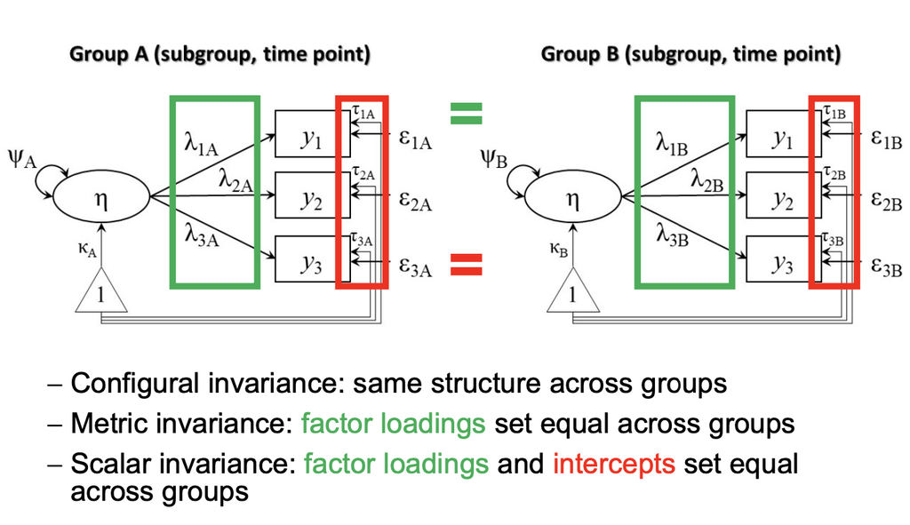

**Configural measurement invariance**

*Equality constraints:*

Equal structure: pattern of factors and relationships of indicators and factors is equal across groups

*Implications:*

Same construct exists across groups; no comparisons of estimates!

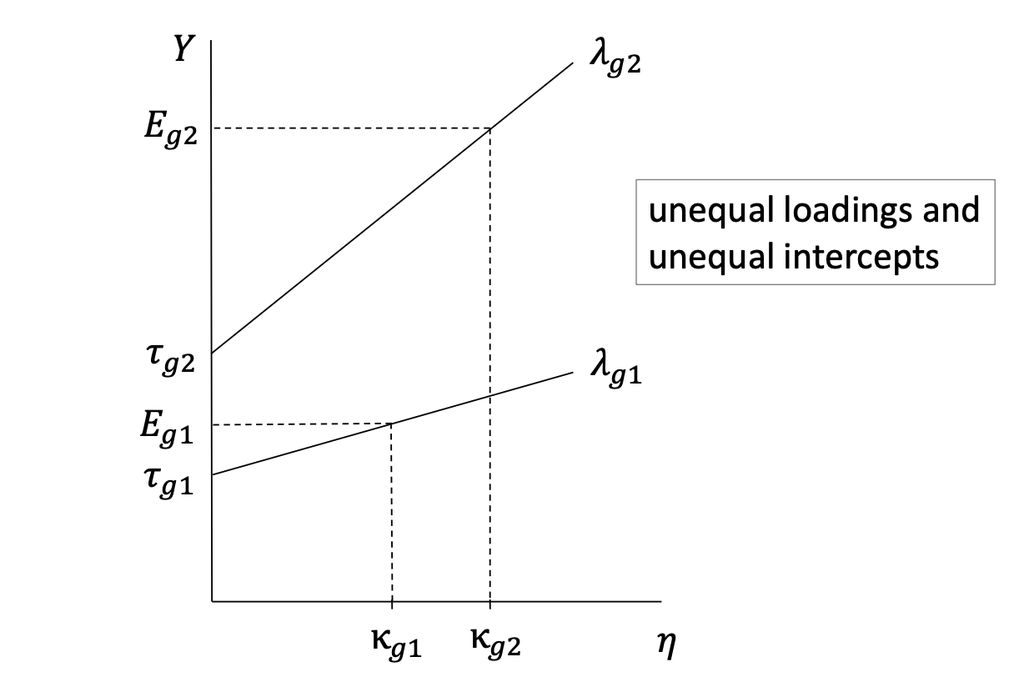

**Metric measurement invariance**

*Equality constraints:*

Equal structure + equal factor loadings across groups

$$\lambda^1 = \lambda^2 =
\lambda^G$$

*Implications:*

Respondents from different groups attribute the same meaning to a construct; comparisons of regression coefficients, correlations, variances are valid.

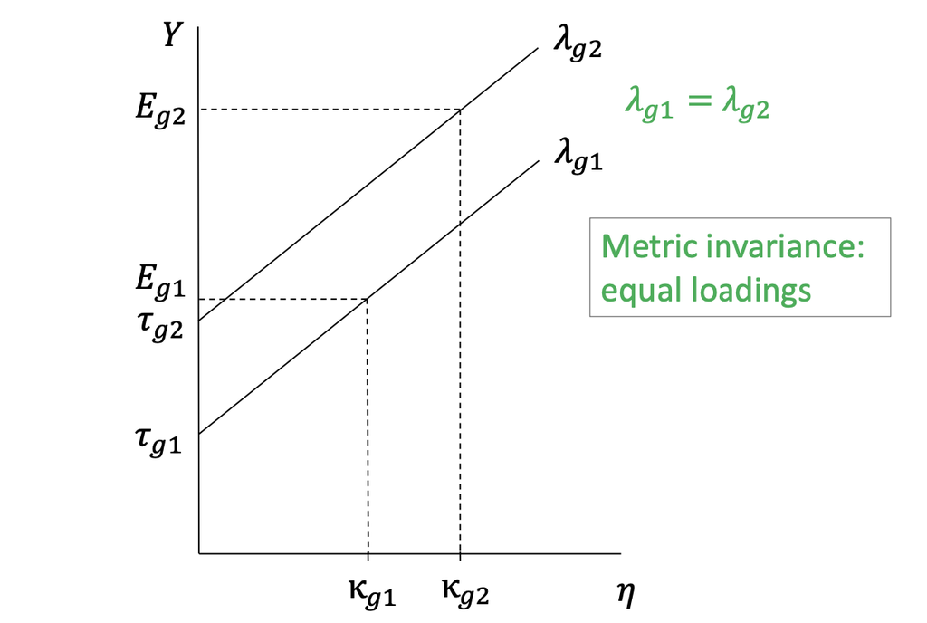

**Scalar measurement invariance**

*Equality constraints:*

Equal structure + equal factor loadings + equal intercepts across groups

$$\begin{split}
\lambda^1 = \lambda^2 = \lambda^G \\
\tau^1 = \tau^2 = \tau^G
\end{split}$$

*Implications:*

Respondents from different groups “use” the scale in a similar manner; comparison of latent means are valid

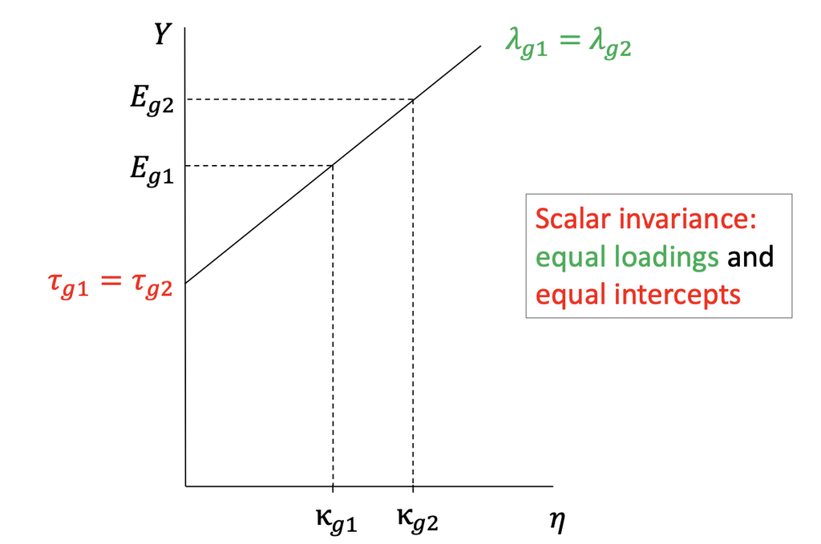

**Result**

- Configural invariance: same structure across groups
- Metric invariance: factor loadings set equal across groups
- Scalar invariance: factor loadings and intercepts set equal across groups

How decide which level of measurement invariance is supported by the data?

1. Consecutively estimate the configural, metric, and scalar invariance models
2. Inspect model fit as usual: $\chi^2$ (df), CFI, RMSEA
3. Inspect model fit differences between models:
   - $\chi^2 / \Delta\chi^2 (df/\Delta df)$
   - $CFI/\Delta CFI;RMSEA/\Delta RMSEA$

**Difference test for two nested models (m1 and m2)**

$\chi^2_d=\chi^2_{m1}-\chi^2_{m2}\ with\ df_{m1}-df_{m2}$

- m1 is nested in m2 if m1 can be derived from m2 by fixing or removing free parameters
- m1 is the simpler model (it has more df)
- $\chi^2_d$ tells us how much m1 fits worse than m2

Traditional $\chi^2$ difference testing is sensitive to sample size!

Guidelines using alternative fit indices - (**chen_sensitivity_2007?**): differences between a constrained model (m1) and a more liberal model (m2) are considered irrelevant when

N $\leq$ 300: $CFI(m1)-CFI(m2)\leq-.005\ and\ RMSEA(m1)-RMSEA(m2)\leq.010$

## MI - Universalism

Do the mean levels of endorsement of universalism values differ across the CZ, DE, and GB?

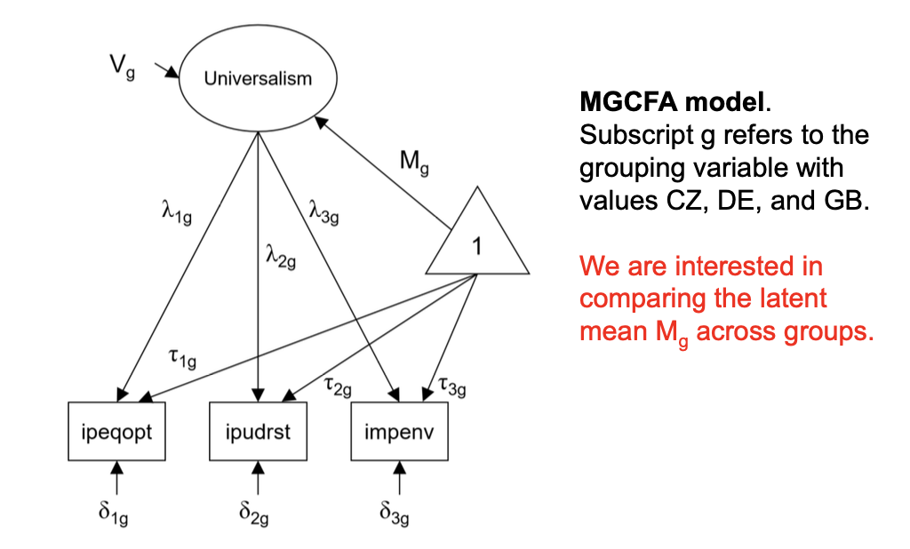

### Individual measurement for each group

Before we can approach a common model across all groups, we have to check whether the envisaged measurement model can be measured properly in each group.

```r
ESS07_countries <- group_split(ESS07, country) %>%
  # optional for better display
  set_names(unique(ESS07$country))
```

We have now split the entire data set into three individual data sets according to the respective countries. These data sets are now checked individually as a measurement model.

**Reference indicator method**

```r
universalism_fit_countries <- ESS07_countries %>%
  map(~ cfa(
    model = "Universalism =~ ipeqopt + ipudrst + impenv",
    data = .,
    estimator = "MLR",
    # optional if there are missing values
    missing = "fiml.x"
    ))
```

```r
universalism_fit_countries %>%
  map(~ summary(
    object = .,
    fit.measures = T,
    standardized = T
    # rsquare = T
  ))
```

```
$CZ
lavaan 0.6-12 ended normally after 24 iterations

  Estimator                                         ML
  Optimization method                           NLMINB
  Number of model parameters                         9

  Number of observations                          1393
  Number of missing patterns                         1

Model Test User Model:
                                              Standard      Robust
  Test Statistic                                 0.000       0.000
  Degrees of freedom                                 0           0

Model Test Baseline Model:

  Test statistic                               405.539     263.905
  Degrees of freedom                                 3           3
  P-value                                        0.000       0.000
  Scaling correction factor                                  1.537

User Model versus Baseline Model:

  Comparative Fit Index (CFI)                    1.000       1.000
  Tucker-Lewis Index (TLI)                       1.000       1.000

  Robust Comparative Fit Index (CFI)                            NA
  Robust Tucker-Lewis Index (TLI)                               NA

Loglikelihood and Information Criteria:

  Loglikelihood user model (H0)              -5999.450   -5999.450
  Loglikelihood unrestricted model (H1)      -5999.450   -5999.450

  Akaike (AIC)                               12016.901   12016.901
  Bayesian (BIC)                             12064.054   12064.054
  Sample-size adjusted Bayesian (BIC)        12035.464   12035.464

Root Mean Square Error of Approximation:
```

[output cut: 189 more lines]

```
    impenv            0.765    0.085    9.011    0.000    0.429    0.396

Intercepts:
                   Estimate  Std.Err  z-value  P(>|z|)   Std.lv  Std.all
   .ipeqopt           4.994    0.025  199.417    0.000    4.994    4.727
   .ipudrst           4.716    0.025  188.538    0.000    4.716    4.469
   .impenv            4.849    0.026  188.959    0.000    4.849    4.479
    Universalism      0.000                               0.000    0.000

Variances:
                   Estimate  Std.Err  z-value  P(>|z|)   Std.lv  Std.all
   .ipeqopt           0.803    0.055   14.701    0.000    0.803    0.719
   .ipudrst           0.614    0.072    8.558    0.000    0.614    0.551
   .impenv            0.988    0.044   22.454    0.000    0.988    0.843
    Universalism      0.314    0.051    6.179    0.000    1.000    1.000
```

In all countries the measurement model reaches an acceptable form. In the next step, we can calculate all countries without constraints in a model and see whether there is an adequate fit here as well.

**Fixed factor method**

```r
universalism_fit_countries2 <- ESS07_countries %>%
  map(~ cfa(
    model = "
    uni =~ NA*ipeqopt + ipudrst + impenv
    uni ~~ 1*uni
    ",
    data = .,
    estimator = "MLR",
    # optional if there are missing values
    missing = "fiml.x"
    ))
```

```r
universalism_fit_countries2 %>%
  map(~ summary(
    object = .,
    fit.measures = T,
    standardized = T
    # rsquare = T
  ))
```

```
$CZ
lavaan 0.6-12 ended normally after 15 iterations

  Estimator                                         ML
  Optimization method                           NLMINB
  Number of model parameters                         9

  Number of observations                          1393
  Number of missing patterns                         1

Model Test User Model:
                                              Standard      Robust
  Test Statistic                                 0.000       0.000
  Degrees of freedom                                 0           0

Model Test Baseline Model:

  Test statistic                               405.539     263.905
  Degrees of freedom                                 3           3
  P-value                                        0.000       0.000
  Scaling correction factor                                  1.537

User Model versus Baseline Model:

  Comparative Fit Index (CFI)                    1.000       1.000
  Tucker-Lewis Index (TLI)                       1.000       1.000

  Robust Comparative Fit Index (CFI)                            NA
  Robust Tucker-Lewis Index (TLI)                               NA

Loglikelihood and Information Criteria:

  Loglikelihood user model (H0)              -5999.450   -5999.450
  Loglikelihood unrestricted model (H1)      -5999.450   -5999.450

  Akaike (AIC)                               12016.901   12016.901
  Bayesian (BIC)                             12064.054   12064.054
  Sample-size adjusted Bayesian (BIC)        12035.464   12035.464

Root Mean Square Error of Approximation:
```

[output cut: 189 more lines]

```
    impenv            0.429    0.041   10.552    0.000    0.429    0.396

Intercepts:
                   Estimate  Std.Err  z-value  P(>|z|)   Std.lv  Std.all
   .ipeqopt           4.994    0.025  199.417    0.000    4.994    4.727
   .ipudrst           4.716    0.025  188.538    0.000    4.716    4.469
   .impenv            4.849    0.026  188.959    0.000    4.849    4.479
    uni               0.000                               0.000    0.000

Variances:
                   Estimate  Std.Err  z-value  P(>|z|)   Std.lv  Std.all
    uni               1.000                               1.000    1.000
   .ipeqopt           0.803    0.055   14.701    0.000    0.803    0.719
   .ipudrst           0.614    0.072    8.558    0.000    0.614    0.551
   .impenv            0.988    0.044   22.454    0.000    0.988    0.843
```

### Configural model

Since the configurale model has no constraints, we only have to name the groups to be compared. This happens in Lavaan mainly via the function argument group = “grouping_variable”. In the more detailed form, we can also name the groups when specifying the model.

**Reference indicator method**

```r
universalism_fit_config <- cfa(
  model = "
    group: [CZ]
    uni =~ ipeqopt + ipudrst + impenv
    group: [DE]
    uni =~ ipeqopt + ipudrst + impenv
    group: [GB]
    uni =~ ipeqopt + ipudrst + impenv
  ",
  data = ESS07,
  estimator = "MLR",
  group = "country",
  # optional if there are missing values
  missing = "fiml.x"
)
```

Lavaan carries out the model specification of the groups with the argument group = “grouping_variable” automatically, unless we want to carry out our own specification. The result is the same.

```r
universalism_fit_config <- cfa(
  model = "uni =~ ipeqopt + ipudrst + impenv",
  data = ESS07,
  estimator = "MLR",
  group = "country",
  # optional if there are missing values
  missing = "fiml.x"
)
```

Nevertheless, it makes sense to keep control of the desired restrictions at the beginning and also in the further course.

```r
summary(
  object = universalism_fit_config,
  fit.measures = T,
  standardized = T
  # rsquare = T
)
```

```
lavaan 0.6-12 ended normally after 71 iterations

  Estimator                                         ML
  Optimization method                           NLMINB
  Number of model parameters                        27

  Number of observations per group:
    CZ                                            1393
    DE                                            2671
    GB                                            1780
  Number of missing patterns per group:
    CZ                                               1
    DE                                               1
    GB                                               1

Model Test User Model:
                                              Standard      Robust
  Test Statistic                                 0.000       0.000
  Degrees of freedom                                 0           0
  Test statistic for each group:
    CZ                                           0.000       0.000
    DE                                           0.000       0.000
    GB                                           0.000       0.000

Model Test Baseline Model:

  Test statistic                              1289.722     877.559
  Degrees of freedom                                 9           9
  P-value                                        0.000       0.000
  Scaling correction factor                                  1.470

User Model versus Baseline Model:

  Comparative Fit Index (CFI)                    1.000       1.000
  Tucker-Lewis Index (TLI)                       1.000       1.000

  Robust Comparative Fit Index (CFI)                            NA
  Robust Tucker-Lewis Index (TLI)                               NA

Loglikelihood and Information Criteria:
```

[output cut: 85 more lines]

```
    impenv            0.765    0.085    9.011    0.000    0.429    0.396

Intercepts:
                   Estimate  Std.Err  z-value  P(>|z|)   Std.lv  Std.all
   .ipeqopt           4.994    0.025  199.417    0.000    4.994    4.727
   .ipudrst           4.716    0.025  188.538    0.000    4.716    4.469
   .impenv            4.849    0.026  188.959    0.000    4.849    4.479
    uni               0.000                               0.000    0.000

Variances:
                   Estimate  Std.Err  z-value  P(>|z|)   Std.lv  Std.all
   .ipeqopt           0.803    0.055   14.701    0.000    0.803    0.719
   .ipudrst           0.614    0.072    8.558    0.000    0.614    0.551
   .impenv            0.988    0.044   22.454    0.000    0.988    0.843
    uni               0.314    0.051    6.179    0.000    1.000    1.000
```

The mean structure is estimated as the default: intercepts are unconstrained, latent means are fixed to zero.

**Result:**

Again, we see that the model works well.

- All parameters differ across groups, the latent means are fixed to zero
- The model is just identified

**Fixed factor method**

```r
universalism_fit_config2 <- cfa(
  model = "
    group: [CZ]
    uni =~ NA*ipeqopt + ipudrst + impenv
    uni ~~ 1*uni
    group: [DE]
    uni =~ NA*ipeqopt + ipudrst + impenv
    uni ~~ 1*uni
    group: [GB]
    uni =~ NA*ipeqopt + ipudrst + impenv
    uni ~~ 1*uni
  ",
  data = ESS07,
  estimator = "MLR",
  group = "country",
  # optional if there are missing values
  missing = "fiml.x"
)
```

```r
summary(
  object = universalism_fit_config2,
  fit.measures = T,
  standardized = T
)
```

```
lavaan 0.6-12 ended normally after 50 iterations

  Estimator                                         ML
  Optimization method                           NLMINB
  Number of model parameters                        27

  Number of observations per group:
    CZ                                            1393
    DE                                            2671
    GB                                            1780
  Number of missing patterns per group:
    CZ                                               1
    DE                                               1
    GB                                               1

Model Test User Model:
                                              Standard      Robust
  Test Statistic                                 0.000       0.000
  Degrees of freedom                                 0           0
  Test statistic for each group:
    CZ                                           0.000       0.000
    DE                                           0.000       0.000
    GB                                           0.000       0.000

Model Test Baseline Model:

  Test statistic                              1289.722     877.559
  Degrees of freedom                                 9           9
  P-value                                        0.000       0.000
  Scaling correction factor                                  1.470

User Model versus Baseline Model:

  Comparative Fit Index (CFI)                    1.000       1.000
  Tucker-Lewis Index (TLI)                       1.000       1.000

  Robust Comparative Fit Index (CFI)                            NA
  Robust Tucker-Lewis Index (TLI)                               NA

Loglikelihood and Information Criteria:
```

[output cut: 85 more lines]

```
    impenv            0.429    0.041   10.552    0.000    0.429    0.396

Intercepts:
                   Estimate  Std.Err  z-value  P(>|z|)   Std.lv  Std.all
   .ipeqopt           4.994    0.025  199.417    0.000    4.994    4.727
   .ipudrst           4.716    0.025  188.538    0.000    4.716    4.469
   .impenv            4.849    0.026  188.959    0.000    4.849    4.479
    uni               0.000                               0.000    0.000

Variances:
                   Estimate  Std.Err  z-value  P(>|z|)   Std.lv  Std.all
    uni               1.000                               1.000    1.000
   .ipeqopt           0.803    0.055   14.701    0.000    0.803    0.719
   .ipudrst           0.614    0.072    8.558    0.000    0.614    0.551
   .impenv            0.988    0.044   22.454    0.000    0.988    0.843
```

### Metric model

Next we want to check whether there is also a metric measurement invariance.

Since we have to equate the factor loadings for the metric measurement invariance (constrains), we have to work with labels in front of the parameters.

**Reference indicator method**

```r
universalism_fit_metric <- cfa(
    model = "
    group: [CZ]
    uni =~ ipeqopt + a*ipudrst + b*impenv
    group: [DE]
    uni =~ ipeqopt + a*ipudrst + b*impenv
    group: [GB]
    uni =~ ipeqopt + a*ipudrst + b*impenv
  ",
  data = ESS07,
  estimator = "MLR",
  group = "country",
  # optional if there are missing values
  missing = "fiml.x"
)
```

Here, too, the model specification can be simplified as required with the argument group.equal = “loadings”.

```r
universalism_fit_metric <- cfa(
  model = "uni =~ ipeqopt + ipudrst + impenv",
  data = ESS07,
  estimator = "MLR",
  group = "country",
  group.equal = "loadings",
  # optional if there are missing values
  missing = "fiml.x"
)
```

However, Lavaan automatically assigns the labels .p[number]., although the effect is the same.

```r
summary(
  object = universalism_fit_metric,
  fit.measures = T,
  standardized = T
  # rsquare = T
)
```

```
lavaan 0.6-12 ended normally after 38 iterations

  Estimator                                         ML
  Optimization method                           NLMINB
  Number of model parameters                        27
  Number of equality constraints                     4

  Number of observations per group:
    CZ                                            1393
    DE                                            2671
    GB                                            1780
  Number of missing patterns per group:
    CZ                                               1
    DE                                               1
    GB                                               1

Model Test User Model:
                                              Standard      Robust
  Test Statistic                                21.133      16.446
  Degrees of freedom                                 4           4
  P-value (Chi-square)                           0.000       0.002
  Scaling correction factor                                  1.285
    Yuan-Bentler correction (Mplus variant)
  Test statistic for each group:
    CZ                                           7.515       5.848
    DE                                           0.684       0.533
    GB                                          12.934      10.065

Model Test Baseline Model:

  Test statistic                              1289.722     877.559
  Degrees of freedom                                 9           9
  P-value                                        0.000       0.000
  Scaling correction factor                                  1.470

User Model versus Baseline Model:

  Comparative Fit Index (CFI)                    0.987       0.986
  Tucker-Lewis Index (TLI)                       0.970       0.968

```

[output cut: 93 more lines]

```
    impenv  (.p3.)    0.910    0.057   16.014    0.000    0.528    0.480

Intercepts:
                   Estimate  Std.Err  z-value  P(>|z|)   Std.lv  Std.all
   .ipeqopt           4.994    0.025  199.417    0.000    4.994    4.731
   .ipudrst           4.716    0.025  188.538    0.000    4.716    4.527
   .impenv            4.849    0.026  188.959    0.000    4.849    4.406
    uni               0.000                               0.000    0.000

Variances:
                   Estimate  Std.Err  z-value  P(>|z|)   Std.lv  Std.all
   .ipeqopt           0.777    0.046   16.714    0.000    0.777    0.698
   .ipudrst           0.728    0.046   16.001    0.000    0.728    0.671
   .impenv            0.932    0.042   22.197    0.000    0.932    0.769
    uni               0.337    0.036    9.238    0.000    1.000    1.000
```

**Results:**

- The model has a good model fit and all factor loadings have sufficient loading.

**Fixed factor method**

```r
universalism_fit_metric2 <- cfa(
    model = "
    group: [CZ]
    uni =~ NA*ipeqopt + a*ipeqopt + b*ipudrst + c*impenv
    uni ~~ 1*uni
    group: [DE]
    uni =~ NA*ipeqopt + a*ipeqopt + b*ipudrst + c*impenv
    uni ~~ 1*uni
    group: [GB]
    uni =~ NA*ipeqopt + a*ipeqopt + b*ipudrst + c*impenv
    uni ~~ 1*uni
  ",
  data = ESS07,
  estimator = "MLR",
  group = "country",
  # optional if there are missing values
  missing = "fiml.x"
)
```

```r
summary(
  object = universalism_fit_metric2,
  fit.measures = T,
  standardized = T
  # rsquare = T
)
```

```
lavaan 0.6-12 ended normally after 33 iterations

  Estimator                                         ML
  Optimization method                           NLMINB
  Number of model parameters                        27
  Number of equality constraints                     6

  Number of observations per group:
    CZ                                            1393
    DE                                            2671
    GB                                            1780
  Number of missing patterns per group:
    CZ                                               1
    DE                                               1
    GB                                               1

Model Test User Model:
                                              Standard      Robust
  Test Statistic                                60.748      45.314
  Degrees of freedom                                 6           6
  P-value (Chi-square)                           0.000       0.000
  Scaling correction factor                                  1.341
    Yuan-Bentler correction (Mplus variant)
  Test statistic for each group:
    CZ                                          22.877      17.065
    DE                                          19.143      14.279
    GB                                          18.728      13.970

Model Test Baseline Model:

  Test statistic                              1289.722     877.559
  Degrees of freedom                                 9           9
  P-value                                        0.000       0.000
  Scaling correction factor                                  1.470

User Model versus Baseline Model:

  Comparative Fit Index (CFI)                    0.957       0.955
  Tucker-Lewis Index (TLI)                       0.936       0.932

```

[output cut: 93 more lines]

```
    impenv     (c)    0.493    0.022   22.485    0.000    0.493    0.454

Intercepts:
                   Estimate  Std.Err  z-value  P(>|z|)   Std.lv  Std.all
   .ipeqopt           4.994    0.025  199.417    0.000    4.994    4.793
   .ipudrst           4.716    0.025  188.538    0.000    4.716    4.589
   .impenv            4.849    0.026  188.959    0.000    4.849    4.462
    uni               0.000                               0.000    0.000

Variances:
                   Estimate  Std.Err  z-value  P(>|z|)   Std.lv  Std.all
    uni               1.000                               1.000    1.000
   .ipeqopt           0.789    0.046   17.195    0.000    0.789    0.727
   .ipudrst           0.755    0.043   17.698    0.000    0.755    0.715
   .impenv            0.938    0.042   22.417    0.000    0.938    0.794
```

### Scalar model

As a final step, we want to see if there is scalar measurement invariance across groups.

For this we have to equate the intercepts in the model specification. As previously shown, Lavaan works syntactically with variable~1 in order to be able to select the intercept of the respective item. In the following we can equate the Intercepts value with a label across all groups.

**Reference indicator method**

```r
universalism_fit_scalar <- cfa(
    model = "
    group: [CZ]
    uni =~ ipeqopt + a*ipudrst + b*impenv
    ipeqopt ~ c*1
    ipudrst ~ d*1
    impenv ~ e*1

    group: [DE]
    uni =~ ipeqopt + a*ipudrst + b*impenv
    ipeqopt ~ c*1
    ipudrst ~ d*1
    impenv ~ e*1

    group: [GB]
    uni =~ ipeqopt + a*ipudrst + b*impenv
    ipeqopt ~ c*1
    ipudrst ~ d*1
    impenv ~ e*1
  ",
  data = ESS07,
  estimator = "MLR",
  group = "country",
  # optional if there are missing values
  missing = "fiml.x"
)
```

Again, there is a function argument that allows a simple calculation of the scalar measurement invariance. If we add intercepts in the argument group.equal = c(“loadings”, “intercepts”), all intercepts are equated across the groups.

```r
universalism_fit_scalar <- cfa(
  model = "uni =~ ipeqopt + ipudrst + impenv",
  data = ESS07,
  estimator = "MLR",
  group = "country",
  group.equal = c("loadings", "intercepts"),
  # optional if there are missing values
  missing = "fiml.x"
)
```

```r
summary(
  object = universalism_fit_scalar,
  fit.measures = T,
  standardized = T
  # rsquare = T
)
```

```
lavaan 0.6-12 ended normally after 46 iterations

  Estimator                                         ML
  Optimization method                           NLMINB
  Number of model parameters                        29
  Number of equality constraints                    10

  Number of observations per group:
    CZ                                            1393
    DE                                            2671
    GB                                            1780
  Number of missing patterns per group:
    CZ                                               1
    DE                                               1
    GB                                               1

Model Test User Model:
                                              Standard      Robust
  Test Statistic                                77.073      65.804
  Degrees of freedom                                 8           8
  P-value (Chi-square)                           0.000       0.000
  Scaling correction factor                                  1.171
    Yuan-Bentler correction (Mplus variant)
  Test statistic for each group:
    CZ                                          51.362      43.853
    DE                                          17.278      14.752
    GB                                           8.433       7.200

Model Test Baseline Model:

  Test statistic                              1289.722     877.559
  Degrees of freedom                                 9           9
  P-value                                        0.000       0.000
  Scaling correction factor                                  1.470

User Model versus Baseline Model:

  Comparative Fit Index (CFI)                    0.946       0.933
  Tucker-Lewis Index (TLI)                       0.939       0.925

```

[output cut: 93 more lines]

```
    impenv  (.p3.)    0.791    0.038   20.559    0.000    0.460    0.423

Intercepts:
                   Estimate  Std.Err  z-value  P(>|z|)   Std.lv  Std.all
   .ipeqopt (.p8.)    4.568    0.026  174.343    0.000    4.568    4.315
   .ipudrst (.p9.)    4.295    0.029  146.756    0.000    4.295    4.088
   .impenv  (.10.)    4.581    0.023  197.095    0.000    4.581    4.209
    uni               0.384    0.031   12.280    0.000    0.659    0.659

Variances:
                   Estimate  Std.Err  z-value  P(>|z|)   Std.lv  Std.all
   .ipeqopt           0.782    0.044   17.679    0.000    0.782    0.698
   .ipudrst           0.667    0.045   14.793    0.000    0.667    0.604
   .impenv            0.973    0.041   23.638    0.000    0.973    0.821
    uni               0.339    0.032   10.471    0.000    1.000    1.000
```

**Results:**

- The latent means have been estimated in group 2 and 3 and fixed in group 1
- Acceptable model fit

**Fixed factor method**

```r
universalism_fit_scalar2 <- cfa(
    model = "
    group: [CZ]
    uni =~ NA*ipeqopt + a*ipeqopt + b*ipudrst + c*impenv
    ipeqopt ~ d*1
    ipudrst ~ e*1
    impenv ~ f*1
    uni ~ 0*1
    uni ~~ 1*uni

    group: [DE]
    uni =~ NA*ipeqopt + a*ipeqopt + b*ipudrst + c*impenv
    ipeqopt ~ d*1
    ipudrst ~ e*1
    impenv ~ f*1
    uni ~ NA*1
    uni ~~ 1*uni

    group: [GB]
    uni =~ NA*ipeqopt + a*ipeqopt + b*ipudrst + c*impenv
    ipeqopt ~ d*1
    ipudrst ~ e*1
    impenv ~ f*1
    uni ~ NA*1
    uni ~~ 1*uni
  ",
  data = ESS07,
  estimator = "MLR",
  group = "country",
  # optional if there are missing values
  missing = "fiml.x"
)
```

```r
summary(
  object = universalism_fit_scalar2,
  fit.measures = T,
  standardized = T
  # rsquare = T
)
```

```
lavaan 0.6-12 ended normally after 39 iterations

  Estimator                                         ML
  Optimization method                           NLMINB
  Number of model parameters                        29
  Number of equality constraints                    12

  Number of observations per group:
    CZ                                            1393
    DE                                            2671
    GB                                            1780
  Number of missing patterns per group:
    CZ                                               1
    DE                                               1
    GB                                               1

Model Test User Model:
                                              Standard      Robust
  Test Statistic                               117.607      95.679
  Degrees of freedom                                10          10
  P-value (Chi-square)                           0.000       0.000
  Scaling correction factor                                  1.229
    Yuan-Bentler correction (Mplus variant)
  Test statistic for each group:
    CZ                                          65.534      53.315
    DE                                          36.365      29.585
    GB                                          15.708      12.779

Model Test Baseline Model:

  Test statistic                              1289.722     877.559
  Degrees of freedom                                 9           9
  P-value                                        0.000       0.000
  Scaling correction factor                                  1.470

User Model versus Baseline Model:

  Comparative Fit Index (CFI)                    0.916       0.901
  Tucker-Lewis Index (TLI)                       0.924       0.911

```

[output cut: 93 more lines]

```
    impenv     (c)    0.423    0.019   22.258    0.000    0.423    0.393

Intercepts:
                   Estimate  Std.Err  z-value  P(>|z|)   Std.lv  Std.all
   .ipeqopt    (d)    4.566    0.026  174.147    0.000    4.566    4.387
   .ipudrst    (e)    4.299    0.029  147.192    0.000    4.299    4.169
   .impenv     (f)    4.579    0.023  197.698    0.000    4.579    4.255
    uni               0.719    0.057   12.639    0.000    0.719    0.719

Variances:
                   Estimate  Std.Err  z-value  P(>|z|)   Std.lv  Std.all
    uni               1.000                               1.000    1.000
   .ipeqopt           0.795    0.044   18.224    0.000    0.795    0.734
   .ipudrst           0.701    0.042   16.860    0.000    0.701    0.659
   .impenv            0.979    0.041   23.793    0.000    0.979    0.845
```

### Comparing fit statistics

Finally, we want to check whether the respective models with tightened measurement invariance do not show any significant deterioration in the data fitting and thus do not falsify the assumption of the corresponding measurement invariances.

```r
compFit.universalism <- compareFit(
  scalar = universalism_fit_scalar,
  metric = universalism_fit_metric,
  config = universalism_fit_config,
  argsLRT = list(method = "satorra.bentler.2001")
)
```

```r
summary(
  object = compFit.universalism,
  fit.measures = c("chisq.scaled", "df.scaled", "pvalue.scaled",
                   "rmsea.scaled", "cfi.scaled", "tli.scaled",
                   "srmr", "aic", "bic")
  )
```

```
################### Nested Model Comparison #########################
Scaled Chi-Squared Difference Test (method = "satorra.bentler.2001")

lavaan NOTE:
    The "Chisq" column contains standard test statistics, not the
    robust test that should be reported per model. A robust difference
    test is a function of two standard (not robust) statistics.

       Df   AIC   BIC  Chisq Chisq diff Df diff Pr(>Chisq)
config  0 48553 48734  0.000
metric  4 48566 48720 21.133     16.446       4   0.002475 **
scalar  8 48614 48741 77.073     52.897       4  8.954e-11 ***
---
Signif. codes:  0 '***' 0.001 '**' 0.01 '*' 0.05 '.' 0.1 ' ' 1

####################### Model Fit Indices ###########################
       chisq.scaled df.scaled pvalue.scaled rmsea.scaled cfi.scaled tli.scaled
config        .000†                      NA        .000†     1.000†     1.000†
metric      16.446          4          .002        .040       .986       .968
scalar      65.804          8          .000        .061       .933       .925
        srmr        aic        bic
config .000† 48553.355† 48733.531
metric .017  48566.488  48719.971†
scalar .032  48614.428  48741.219

################## Differences in Fit Indices #######################
                df.scaled rmsea.scaled cfi.scaled tli.scaled  srmr    aic
metric - config         4        0.040     -0.014     -0.032 0.017 13.133
scalar - metric         4        0.021     -0.052     -0.043 0.015 47.940
                    bic
metric - config -13.559
scalar - metric  21.247
```

**Results:**

- $\chi^2$ differences are significant = The different levels of measurement invariance deviate significantly from each other and show a poorer fit to the data
- Alternative fit indices also show that there is no metric or scalar measurement invariance

**Fixed factor method**

```r
compFit.universalism2 <- compareFit(
  scalar = universalism_fit_scalar2,
  metric = universalism_fit_metric2,
  config = universalism_fit_config2,
  argsLRT = list(method = "satorra.bentler.2001")
)
```

```r
summary(
  object = compFit.universalism2,
  fit.measures = c("chisq.scaled", "df.scaled", "pvalue.scaled",
                   "rmsea.scaled", "cfi.scaled", "tli.scaled",
                   "srmr", "aic", "bic")
  )
```

```
################### Nested Model Comparison #########################
Scaled Chi-Squared Difference Test (method = "satorra.bentler.2001")

lavaan NOTE:
    The "Chisq" column contains standard test statistics, not the
    robust test that should be reported per model. A robust difference
    test is a function of two standard (not robust) statistics.

       Df   AIC   BIC   Chisq Chisq diff Df diff Pr(>Chisq)
config  0 48553 48734   0.000
metric  6 48602 48742  60.748     45.314       6  4.054e-08 ***
scalar 10 48651 48764 117.607     53.537       4  6.580e-11 ***
---
Signif. codes:  0 '***' 0.001 '**' 0.01 '*' 0.05 '.' 0.1 ' ' 1

####################### Model Fit Indices ###########################
       chisq.scaled df.scaled pvalue.scaled rmsea.scaled cfi.scaled tli.scaled
config        .000†                      NA        .000†     1.000†     1.000†
metric      45.314          6          .000        .058       .955       .932
scalar      95.679         10          .000        .066       .901       .911
        srmr        aic        bic
config .000† 48553.355† 48733.531†
metric .048  48602.103  48742.239
scalar .054  48650.962  48764.406

################## Differences in Fit Indices #######################
                df.scaled rmsea.scaled cfi.scaled tli.scaled  srmr    aic
metric - config         6        0.058     -0.045     -0.068 0.048 48.748
scalar - metric         4        0.008     -0.053     -0.021 0.006 48.859
                   bic
metric - config  8.709
scalar - metric 22.167
```

# Partial measurement invariance

Partial measurement invariance (**byrne_testing_1989?**)

- In contrast to “full” MI only a few parameters are kept invariant
- Two indicators with invariant loadings and intercepts are sufficient for valid latent mean comparisons
  - Step 1: identify misspecified equality constraints and relax them (-> modification indices)
  - Step 2: re-estimate and compare with the previous (full) MI models

## Partial MI - Universalism

Since we only calculate three factor loadings in our measurement model and we only have a partial measurement invariance if two factor loadings are measurement invariant, we have to use the fixed factor method to calculate all factor loadings.

- The lavTestScore command contains the score test results informing about which contraints are troublesome
- The command parTable tells us which labels are used for each parameter of the model

```r
universalism_fit_metric2 %>%
  lavTestScore() %>%
  # optional for better display
  export_table(table_width = 1, digits = 2)
```

```
test  |    X2 | df |  p.value
-----------------------------
score | 61.17 |  6 | 2.61e-11

lhs  | op |   rhs |    X2 | df |  p.value
-----------------------------------------
.p1. | == | .p12. | 15.13 |  1 | 1.00e-04
.p1. | == | .p23. |  3.57 |  1 |     0.06
.p2. | == | .p13. | 26.81 |  1 | 2.25e-07
.p2. | == | .p24. | 19.73 |  1 | 8.94e-06
.p3. | == | .p14. |  9.40 |  1 | 2.17e-03
.p3. | == | .p25. |  2.12 |  1 |     0.15
```

- Total score test: $\chi^2$ reduction if all constraints were removed
- Univariate score tests: $\chi^2$ reduction for removing a single constraint

.p2. == .p13. -> Constraint with the largest $\chi^2$ reduction

What do the parameter labels (.p2. & .p13.) mean?

```r
universalism_fit_metric2 %>%
  parTable() %>%
  select(lhs, op, rhs, group, label, plabel, est, se) %>%
  # optional for better display
  export_table(table_width = 1, digits = 2)
```

```
lhs     | op |     rhs | group | label | plabel |       est |   se
------------------------------------------------------------------
uni     | =~ | ipeqopt |  [CZ] |     a |   .p1. |      0.54 | 0.02
uni     | =~ | ipudrst |  [CZ] |     b |   .p2. |      0.55 | 0.02
uni     | =~ |  impenv |  [CZ] |     c |   .p3. |      0.49 | 0.02
uni     | ~~ |     uni |  [CZ] |       |   .p4. |      1.00 | 0.00
ipeqopt | ~~ | ipeqopt |  [CZ] |       |   .p5. |      0.77 | 0.05
ipudrst | ~~ | ipudrst |  [CZ] |       |   .p6. |      0.84 | 0.05
impenv  | ~~ |  impenv |  [CZ] |       |   .p7. |      0.78 | 0.04
ipeqopt | ~1 |         |  [CZ] |       |   .p8. |      4.54 | 0.03
ipudrst | ~1 |         |  [CZ] |       |   .p9. |      4.25 | 0.03
impenv  | ~1 |         |  [CZ] |       |  .p10. |      4.69 | 0.03
uni     | ~1 |         |  [CZ] |       |  .p11. |      0.00 | 0.00
uni     | =~ | ipeqopt |  [DE] |     a |  .p12. |      0.54 | 0.02
uni     | =~ | ipudrst |  [DE] |     b |  .p13. |      0.55 | 0.02
uni     | =~ |  impenv |  [DE] |     c |  .p14. |      0.49 | 0.02
uni     | ~~ |     uni |  [DE] |       |  .p15. |      1.00 | 0.00
ipeqopt | ~~ | ipeqopt |  [DE] |       |  .p16. |      0.67 | 0.04
ipudrst | ~~ | ipudrst |  [DE] |       |  .p17. |      0.52 | 0.03
impenv  | ~~ |  impenv |  [DE] |       |  .p18. |      0.70 | 0.03
ipeqopt | ~1 |         |  [DE] |       |  .p19. |      5.13 | 0.02
ipudrst | ~1 |         |  [DE] |       |  .p20. |      4.96 | 0.02
impenv  | ~1 |         |  [DE] |       |  .p21. |      5.00 | 0.02
uni     | ~1 |         |  [DE] |       |  .p22. |      0.00 | 0.00
uni     | =~ | ipeqopt |  [GB] |     a |  .p23. |      0.54 | 0.02
uni     | =~ | ipudrst |  [GB] |     b |  .p24. |      0.55 | 0.02
uni     | =~ |  impenv |  [GB] |     c |  .p25. |      0.49 | 0.02
uni     | ~~ |     uni |  [GB] |       |  .p26. |      1.00 | 0.00
ipeqopt | ~~ | ipeqopt |  [GB] |       |  .p27. |      0.79 | 0.05
ipudrst | ~~ | ipudrst |  [GB] |       |  .p28. |      0.76 | 0.04
impenv  | ~~ |  impenv |  [GB] |       |  .p29. |      0.94 | 0.04
ipeqopt | ~1 |         |  [GB] |       |  .p30. |      4.99 | 0.03
ipudrst | ~1 |         |  [GB] |       |  .p31. |      4.72 | 0.03
impenv  | ~1 |         |  [GB] |       |  .p32. |      4.85 | 0.03
uni     | ~1 |         |  [GB] |       |  .p33. |      0.00 | 0.00
.p1.    | == |   .p12. |       |       |        | -1.11e-16 | 0.00
.p1.    | == |   .p23. |       |       |        |  1.11e-16 | 0.00
.p2.    | == |   .p13. |       |       |        | -1.11e-16 | 0.00
.p2.    | == |   .p24. |       |       |        |  3.33e-16 | 0.00
.p3.    | == |   .p14. |       |       |        | -2.78e-16 | 0.00
.p3.    | == |   .p25. |       |       |        |  1.67e-16 | 0.00
```

Obviously, we achieve the largest $\chi^2$ reduction in the metric invariance model by freely calculating the factor loading of item ipudrst, because there is a clear difference between group CZ and DE.

### Partial metric invariance

```r
universalism_fit_metric_partial <- cfa(
    model = "
    group: [CZ]
    uni =~ NA*ipeqopt + a*ipeqopt + NA*ipudrst + c*impenv
    uni ~~ 1*uni
    group: [DE]
    uni =~ NA*ipeqopt + a*ipeqopt + NA*ipudrst + c*impenv
    uni ~~ 1*uni
    group: [GB]
    uni =~ NA*ipeqopt + a*ipeqopt + NA*ipudrst + c*impenv
    uni ~~ 1*uni
  ",
  data = ESS07,
  estimator = "MLR",
  group = "country",
  # optional if there are missing values
  missing = "fiml.x"
)
```

```r
summary(
  universalism_fit_metric_partial,
  fit.measures = T,
  standardized = T
  # rsquare = T
)
```

```
lavaan 0.6-12 ended normally after 39 iterations

  Estimator                                         ML
  Optimization method                           NLMINB
  Number of model parameters                        27
  Number of equality constraints                     4

  Number of observations per group:
    CZ                                            1393
    DE                                            2671
    GB                                            1780
  Number of missing patterns per group:
    CZ                                               1
    DE                                               1
    GB                                               1

Model Test User Model:
                                              Standard      Robust
  Test Statistic                                31.211      23.802
  Degrees of freedom                                 4           4
  P-value (Chi-square)                           0.000       0.000
  Scaling correction factor                                  1.311
    Yuan-Bentler correction (Mplus variant)
  Test statistic for each group:
    CZ                                          22.081      16.839
    DE                                           5.650       4.308
    GB                                           3.481       2.655

Model Test Baseline Model:

  Test statistic                              1289.722     877.559
  Degrees of freedom                                 9           9
  P-value                                        0.000       0.000
  Scaling correction factor                                  1.470

User Model versus Baseline Model:

  Comparative Fit Index (CFI)                    0.979       0.977
  Tucker-Lewis Index (TLI)                       0.952       0.949

```

[output cut: 93 more lines]

```
    impenv     (c)    0.489    0.022   22.314    0.000    0.489    0.446

Intercepts:
                   Estimate  Std.Err  z-value  P(>|z|)   Std.lv  Std.all
   .ipeqopt           4.994    0.025  199.417    0.000    4.994    4.742
   .ipudrst           4.716    0.025  188.538    0.000    4.716    4.461
   .impenv            4.849    0.026  188.959    0.000    4.849    4.425
    uni               0.000                               0.000    0.000

Variances:
                   Estimate  Std.Err  z-value  P(>|z|)   Std.lv  Std.all
    uni               1.000                               1.000    1.000
   .ipeqopt           0.816    0.045   18.040    0.000    0.816    0.736
   .ipudrst           0.627    0.060   10.512    0.000    0.627    0.561
   .impenv            0.962    0.042   22.668    0.000    0.962    0.801
```

**Comparing fit statistics**

Finally, we want to check whether the respective models with tightened measurement invariance do not show any significant deterioration in the data fitting and thus do not falsify the assumption of the corresponding measurement invariances.

```r
compFit.universalism2 <- compareFit(
  # scalar = universalism_fit_scalar2,
  metric = universalism_fit_metric_partial,
  config = universalism_fit_config2,
  argsLRT = list(method = "satorra.bentler.2001")
)
```

```r
summary(
  object = compFit.universalism2,
  fit.measures = c("chisq.scaled", "df.scaled", "pvalue.scaled",
                   "rmsea.scaled", "cfi.scaled", "tli.scaled",
                   "srmr", "aic", "bic")
  )
```

```
################### Nested Model Comparison #########################
Scaled Chi-Squared Difference Test (method = "satorra.bentler.2001")

lavaan NOTE:
    The "Chisq" column contains standard test statistics, not the
    robust test that should be reported per model. A robust difference
    test is a function of two standard (not robust) statistics.

       Df   AIC   BIC  Chisq Chisq diff Df diff Pr(>Chisq)
config  0 48553 48734  0.000
metric  4 48577 48730 31.211     23.802       4  8.753e-05 ***
---
Signif. codes:  0 '***' 0.001 '**' 0.01 '*' 0.05 '.' 0.1 ' ' 1

####################### Model Fit Indices ###########################
       chisq.scaled df.scaled pvalue.scaled rmsea.scaled cfi.scaled tli.scaled
config        .000†                      NA        .000†     1.000†     1.000†
metric      23.802          4          .000        .050       .977       .949
        srmr        aic        bic
config .000† 48553.355† 48733.531
metric .028  48576.566  48730.049†

################## Differences in Fit Indices #######################
                df.scaled rmsea.scaled cfi.scaled tli.scaled  srmr    aic
metric - config         4         0.05     -0.023     -0.051 0.028 23.211
                   bic
metric - config -3.481
```

CFI and RMSEA differences are too large according to (**chen_sensitivity_2007?**), but overall acceptable. As a result, it is due to our consideration whether we have a metric measurement invariance here. It can be argued that the deviation in the CFI and RMSEA is negligible and the measurement model with metric invariance has a very good data fit. In this case we follow this reasoning and check further for scalar measurement invariance.

### Partial scalar invariance

```r
universalism_fit_scalar_partial <- cfa(
    model = "
    group: [CZ]
    uni =~ NA*ipeqopt + a*ipeqopt + NA*ipudrst + c*impenv
    ipeqopt ~ d*1
    ipudrst ~ e*1
    impenv ~ f*1
    uni ~ 0*1
    uni ~~ 1*uni

    group: [DE]
    uni =~ NA*ipeqopt + a*ipeqopt + NA*ipudrst + c*impenv
    ipeqopt ~ d*1
    ipudrst ~ e*1
    impenv ~ f*1
    uni ~ NA*1
    uni ~~ 1*uni

    group: [GB]
    uni =~ NA*ipeqopt + a*ipeqopt + NA*ipudrst + c*impenv
    ipeqopt ~ d*1
    ipudrst ~ e*1
    impenv ~ f*1
    uni ~ NA*1
    uni ~~ 1*uni
  ",
  data = ESS07,
  estimator = "MLR",
  group = "country",
  # optional if there are missing values
  missing = "fiml.x"
)
```

```r
summary(
  object = universalism_fit_scalar_partial,
  fit.measures = T,
  standardized = T
  # rsquare = T
)
```

```
lavaan 0.6-12 ended normally after 44 iterations

  Estimator                                         ML
  Optimization method                           NLMINB
  Number of model parameters                        29
  Number of equality constraints                    10

  Number of observations per group:
    CZ                                            1393
    DE                                            2671
    GB                                            1780
  Number of missing patterns per group:
    CZ                                               1
    DE                                               1
    GB                                               1

Model Test User Model:
                                              Standard      Robust
  Test Statistic                               114.782      95.230
  Degrees of freedom                                 8           8
  P-value (Chi-square)                           0.000       0.000
  Scaling correction factor                                  1.205
    Yuan-Bentler correction (Mplus variant)
  Test statistic for each group:
    CZ                                          66.571      55.231
    DE                                          33.709      27.967
    GB                                          14.502      12.032

Model Test Baseline Model:

  Test statistic                              1289.722     877.559
  Degrees of freedom                                 9           9
  P-value                                        0.000       0.000
  Scaling correction factor                                  1.470

User Model versus Baseline Model:

  Comparative Fit Index (CFI)                    0.917       0.900
  Tucker-Lewis Index (TLI)                       0.906       0.887

```

[output cut: 93 more lines]

```
    impenv     (c)    0.420    0.019   21.686    0.000    0.420    0.390

Intercepts:
                   Estimate  Std.Err  z-value  P(>|z|)   Std.lv  Std.all
   .ipeqopt    (d)    4.573    0.027  167.902    0.000    4.573    4.380
   .ipudrst    (e)    4.301    0.029  145.945    0.000    4.301    4.146
   .impenv     (f)    4.582    0.024  193.560    0.000    4.582    4.256
    uni               0.689    0.067   10.278    0.000    0.689    0.689

Variances:
                   Estimate  Std.Err  z-value  P(>|z|)   Std.lv  Std.all
    uni               1.000                               1.000    1.000
   .ipeqopt           0.809    0.047   17.303    0.000    0.809    0.742
   .ipudrst           0.665    0.057   11.690    0.000    0.665    0.618
   .impenv            0.983    0.042   23.610    0.000    0.983    0.848
```

```r
compFit.universalism3 <- compareFit(
  scalar = universalism_fit_scalar_partial,
  metric = universalism_fit_metric_partial,
  config = universalism_fit_config2,
  argsLRT = list(method = "satorra.bentler.2001")
)
```

```r
summary(
  object = compFit.universalism3,
  fit.measures = c("chisq.scaled", "df.scaled", "pvalue.scaled",
                   "rmsea.scaled", "cfi.scaled", "tli.scaled",
                   "srmr", "aic", "bic")
  )
```

```
################### Nested Model Comparison #########################
Scaled Chi-Squared Difference Test (method = "satorra.bentler.2001")

lavaan NOTE:
    The "Chisq" column contains standard test statistics, not the
    robust test that should be reported per model. A robust difference
    test is a function of two standard (not robust) statistics.

       Df   AIC   BIC   Chisq Chisq diff Df diff Pr(>Chisq)
config  0 48553 48734   0.000
metric  4 48577 48730  31.211     23.802       4  8.753e-05 ***
scalar  8 48652 48779 114.782     76.020       4  1.212e-15 ***
---
Signif. codes:  0 '***' 0.001 '**' 0.01 '*' 0.05 '.' 0.1 ' ' 1

####################### Model Fit Indices ###########################
       chisq.scaled df.scaled pvalue.scaled rmsea.scaled cfi.scaled tli.scaled
config        .000†                      NA        .000†     1.000†     1.000†
metric      23.802          4          .000        .050       .977       .949
scalar      95.230          8          .000        .075       .900       .887
        srmr        aic        bic
config .000† 48553.355† 48733.531
metric .028  48576.566  48730.049†
scalar .050  48652.137  48778.927

################## Differences in Fit Indices #######################
                df.scaled rmsea.scaled cfi.scaled tli.scaled  srmr    aic
metric - config         4        0.050     -0.023     -0.051 0.028 23.211
scalar - metric         4        0.024     -0.078     -0.062 0.023 75.570
                   bic
metric - config -3.481
scalar - metric 48.878
```

This also shows that we have to weigh up a rather critical case. The CFI and RMSEA deteriorate significantly and the fit to the data is also borderline. In this respect, it is a question of the researcher which point of view he wants to represent. As an example, we assume scalar measurement invariance here and consider the relative latent means, although we would rather assume no partial scalar measurement invariance here. In this case we would rather choose to use an approximate method.

**Result**

So we can see that in relation to CZ the countries DE and GB have a significantly higher latent mean (see Intercepts uni).